# Technology mediation in child sexual exploitation and abuse in Africa and Asia

## Subset Variables of Interest

```r
ocsea_df <- df_wgt %>%
  select(
    contains("CBU_ID"),
    starts_with("abuse_"),
    starts_with("family_"),
    starts_with("toldnoone_"),
    starts_with("police_"),
    starts_with("friend_"),
    starts_with("helpline_"),
    starts_with("sworker_"),
    starts_with("father_"),
    starts_with("sibling_"),
    starts_with("mother_"),
    starts_with("teacher_"),
    starts_with("other_"),
    starts_with("othera_"),
    starts_with("rprefer_"),
    starts_with("rdontknow_"),
    starts_with("unknown_"),
    starts_with("unknown2_"),
    starts_with("unknown3_"),
    starts_with("perpnotsay"),
    starts_with("known_"),
    starts_with("knownr_"),
    starts_with("knowno_"),
    starts_with("knowno2_"),
    starts_with("socialmedia_"),
    starts_with("inperson_"),
    starts_with("onlinegame_"),
    starts_with("someoway_"),
    starts_with("pnotsay_"),
    starts_with("dontknow_"),
    starts_with("platform_"),
    starts_with("unable_"),
    starts_with("ashamed_"),
    starts_with("disbelief_"),
    starts_with("trouble_"),
    starts_with("troublefam_"),
    starts_with("myfault_"),
    starts_with("notserious_"),
    starts_with("knowledge_"),
    starts_with("troubleother_"),
    starts_with("noaction_"),
    starts_with("friendsdis_"),
    starts_with("parentsdis_"),
    starts_with("noconfidential_"),
    starts_with("pm_"),
    contains("sex"),
    contains("wgt_"),
    contains("age"),
    contains("sexed"),
    contains("COUNTRY"),
    contains("helpseeking"),
    contains("urbanrural"),
    contains("digitalskills"),
    contains("presex"),
    contains("mendecide"),
    contains("malerep"),
    contains("violence")
  )
```

### Weighted Descriptives

```r
# checking sum of weights
weights <- sum(ocsea_df$wgt_scaled, na.rm = TRUE)

# comparing it with our sample size
observations <- nrow(ocsea_df)
observations
```

```
[1] 11912
```

```r
# survey object
svy_overall <-
  survey::svydesign(
    id = ~1,
    weights = ~wgt_scaled,
    data = ocsea_df
  )

# weighted summaries
demographics <-
svy_overall %>%
 tbl_svysummary(
    by = COUNTRY,
    include = c(sex, age, urbanrural)
  ) %>%
  add_overall()
demographics
```

| **Characteristic** | **Overall** N = 11,912<sup>1</sup> | **Cambodia** N = 992<sup>1</sup> | **Ethiopia** N = 1,000<sup>1</sup> | **Indonesia** N = 995<sup>1</sup> | **Kenya** N = 1,014<sup>1</sup> | **Malaysia** N = 995<sup>1</sup> | **Mozambique** N = 999<sup>1</sup> | **Namibia** N = 994<sup>1</sup> | **Philippines** N = 950<sup>1</sup> | **Tanzania** N = 996<sup>1</sup> | **Thailand** N = 967<sup>1</sup> | **Uganda** N = 1,016<sup>1</sup> | **Vietnam** N = 994<sup>1</sup> |
| --- | --- | --- | --- | --- | --- | --- | --- | --- | --- | --- | --- | --- | --- |
| sex |  |  |  |  |  |  |  |  |  |  |  |  |  |
| Boy | 6,044 (51%) | 518 (52%) | 639 (64%) | 451 (45%) | 480 (47%) | 517 (52%) | 522 (52%) | 496 (50%) | 421 (44%) | 561 (56%) | 411 (42%) | 572 (56%) | 455 (46%) |
| Girl | 5,868 (49%) | 474 (48%) | 361 (36%) | 544 (55%) | 534 (53%) | 478 (48%) | 477 (48%) | 498 (50%) | 529 (56%) | 435 (44%) | 556 (58%) | 444 (44%) | 539 (54%) |
| age |  |  |  |  |  |  |  |  |  |  |  |  |  |
| 12 | 1,412 (12%) | 151 (15%) | 43 (4.3%) | 139 (14%) | 129 (13%) | 152 (15%) | 87 (8.7%) | 117 (12%) | 155 (16%) | 91 (9.2%) | 138 (14%) | 60 (5.9%) | 150 (15%) |
| 13 | 1,700 (14%) | 160 (16%) | 81 (8.1%) | 156 (16%) | 165 (16%) | 155 (16%) | 120 (12%) | 147 (15%) | 154 (16%) | 140 (14%) | 158 (16%) | 98 (9.7%) | 164 (17%) |
| 14 | 1,896 (16%) | 166 (17%) | 125 (13%) | 169 (17%) | 156 (15%) | 164 (17%) | 143 (14%) | 173 (17%) | 158 (17%) | 169 (17%) | 162 (17%) | 139 (14%) | 170 (17%) |
| 15 | 2,058 (17%) | 173 (17%) | 141 (14%) | 173 (17%) | 162 (16%) | 172 (17%) | 174 (17%) | 187 (19%) | 162 (17%) | 185 (19%) | 171 (18%) | 186 (18%) | 173 (17%) |
| 16 | 2,311 (19%) | 164 (17%) | 241 (24%) | 177 (18%) | 192 (19%) | 178 (18%) | 239 (24%) | 183 (18%) | 160 (17%) | 200 (20%) | 173 (18%) | 233 (23%) | 171 (17%) |
| 17 | 2,535 (21%) | 178 (18%) | 369 (37%) | 180 (18%) | 210 (21%) | 174 (18%) | 236 (24%) | 188 (19%) | 160 (17%) | 210 (21%) | 164 (17%) | 299 (29%) | 166 (17%) |
| urbanrural |  |  |  |  |  |  |  |  |  |  |  |  |  |
| Peri urban | 1,177 (9.9%) | 160 (16%) | 152 (15%) | 160 (16%) | 25 (2.4%) | 201 (20%) | 69 (6.9%) | 53 (5.3%) | 95 (10.0%) | 26 (2.6%) | 82 (8.4%) | 56 (5.5%) | 100 (10%) |
| Rural | 6,586 (55%) | 678 (68%) | 526 (53%) | 519 (52%) | 650 (64%) | 340 (34%) | 502 (50%) | 470 (47%) | 459 (48%) | 575 (58%) | 534 (55%) | 681 (67%) | 651 (65%) |
| Urban | 4,149 (35%) | 155 (16%) | 322 (32%) | 316 (32%) | 339 (33%) | 454 (46%) | 428 (43%) | 471 (47%) | 396 (42%) | 395 (40%) | 351 (36%) | 280 (28%) | 243 (24%) |

<sup>1</sup> n (%)

### Technology-facilitated CSEA Likert Responses

To understand the prevalence of technology-facilitated CSEA , we use the question (“In the past year, how often have these things happened to you”) to measure whether the child has experienced abuse or exploitation. In total, there are 9 sub-questions, each inquiring about a specific type of abuse. The answers to these sub-questions are originally captured on an ordinal scale ranging from 1 to 5:(1) Never (2) Rarely (3) Sometimes (4) Often (5) Very Often.

| **Characteristic** | **Overall** N = 11,912<sup>1</sup> | **Cambodia** N = 992<sup>1</sup> | **Ethiopia** N = 1,000<sup>1</sup> | **Indonesia** N = 995<sup>1</sup> | **Kenya** N = 1,014<sup>1</sup> | **Malaysia** N = 995<sup>1</sup> | **Mozambique** N = 999<sup>1</sup> | **Namibia** N = 994<sup>1</sup> | **Philippines** N = 950<sup>1</sup> | **Tanzania** N = 996<sup>1</sup> | **Thailand** N = 967<sup>1</sup> | **Uganda** N = 1,016<sup>1</sup> | **Vietnam** N = 994<sup>1</sup> |
| --- | --- | --- | --- | --- | --- | --- | --- | --- | --- | --- | --- | --- | --- |
| abuse_a |  |  |  |  |  |  |  |  |  |  |  |  |  |
| 1 | 9,488 (80%) | 771 (78%) | 715 (72%) | 889 (89%) | 777 (77%) | 870 (87%) | 766 (77%) | 806 (81%) | 622 (65%) | 891 (89%) | 775 (80%) | 726 (72%) | 880 (89%) |
| 2 | 898 (7.5%) | 87 (8.8%) | 95 (9.5%) | 47 (4.7%) | 88 (8.6%) | 58 (5.8%) | 71 (7.1%) | 62 (6.3%) | 156 (16%) | 38 (3.8%) | 46 (4.7%) | 82 (8.1%) | 68 (6.8%) |
| 3 | 775 (6.5%) | 52 (5.3%) | 66 (6.6%) | 21 (2.1%) | 92 (9.0%) | 29 (2.9%) | 105 (10%) | 84 (8.5%) | 96 (10%) | 9 (0.9%) | 76 (7.9%) | 132 (13%) | 12 (1.2%) |
| 4 | 172 (1.4%) | 10 (1.0%) | 25 (2.5%) | 3 (0.3%) | 21 (2.1%) | 3 (0.3%) | 11 (1.1%) | 24 (2.4%) | 13 (1.4%) | 3 (0.3%) | 30 (3.1%) | 27 (2.7%) | 2 (0.2%) |
| 5 | 63 (0.5%) | 6 (0.6%) | 5 (0.5%) | 1 (<0.1%) | 12 (1.1%) | 1 (0.1%) | 7 (0.7%) | 5 (0.5%) | 0 (0%) | 0 (0%) | 15 (1.5%) | 12 (1.1%) | 0 (0%) |
| 888 | 169 (1.4%) | 18 (1.8%) | 11 (1.1%) | 18 (1.8%) | 12 (1.2%) | 21 (2.2%) | 23 (2.3%) | 4 (0.4%) | 27 (2.8%) | 2 (0.2%) | 12 (1.2%) | 12 (1.2%) | 10 (1.0%) |
| 999 | 346 (2.9%) | 48 (4.8%) | 82 (8.2%) | 17 (1.7%) | 13 (1.2%) | 13 (1.3%) | 17 (1.7%) | 10 (1.0%) | 36 (3.8%) | 53 (5.3%) | 13 (1.3%) | 24 (2.3%) | 22 (2.3%) |
| abuse_b |  |  |  |  |  |  |  |  |  |  |  |  |  |
| 1 | 9,545 (80%) | 772 (78%) | 727 (73%) | 891 (90%) | 793 (78%) | 882 (89%) | 700 (70%) | 827 (83%) | 618 (65%) | 895 (90%) | 796 (82%) | 723 (71%) | 922 (93%) |
| 2 | 815 (6.8%) | 75 (7.5%) | 99 (9.9%) | 36 (3.6%) | 71 (7.0%) | 60 (6.1%) | 74 (7.4%) | 55 (5.5%) | 147 (15%) | 39 (3.9%) | 25 (2.6%) | 89 (8.8%) | 45 (4.5%) |
| 3 | 813 (6.8%) | 71 (7.1%) | 54 (5.4%) | 22 (2.2%) | 98 (9.6%) | 23 (2.3%) | 135 (14%) | 74 (7.4%) | 108 (11%) | 6 (0.6%) | 64 (6.6%) | 153 (15%) | 6 (0.6%) |
| 4 | 175 (1.5%) | 12 (1.2%) | 26 (2.6%) | 5 (0.5%) | 20 (2.0%) | 2 (0.2%) | 20 (2.0%) | 19 (1.9%) | 21 (2.2%) | 2 (0.2%) | 34 (3.5%) | 14 (1.3%) | 1 (<0.1%) |
| 5 | 99 (0.8%) | 3 (0.3%) | 7 (0.7%) | 1 (<0.1%) | 11 (1.1%) | 0 (0%) | 30 (3.0%) | 8 (0.8%) | 3 (0.3%) | 2 (0.2%) | 27 (2.8%) | 7 (0.7%) | 0 (0%) |
| 888 | 184 (1.5%) | 12 (1.2%) | 14 (1.4%) | 29 (2.9%) | 13 (1.3%) | 19 (1.9%) | 33 (3.4%) | 5 (0.5%) | 17 (1.8%) | 3 (0.3%) | 10 (1.1%) | 18 (1.8%) | 10 (1.0%) |
| 999 | 280 (2.4%) | 47 (4.8%) | 73 (7.3%) | 12 (1.2%) | 8 (0.8%) | 8 (0.8%) | 7 (0.7%) | 6 (0.6%) | 36 (3.8%) | 49 (4.9%) | 10 (1.0%) | 12 (1.2%) | 11 (1.1%) |
| abuse_c |  |  |  |  |  |  |  |  |  |  |  |  |  |
| 1 | 10,199 (86%) | 839 (85%) | 780 (78%) | 934 (94%) | 861 (85%) | 903 (91%) | 848 (85%) | 890 (90%) | 719 (76%) | 881 (88%) | 827 (86%) | 758 (75%) | 958 (96%) |
| 2 | 614 (5.2%) | 55 (5.5%) | 62 (6.2%) | 17 (1.7%) | 58 (5.7%) | 34 (3.4%) | 46 (4.6%) | 33 (3.3%) | 116 (12%) | 47 (4.7%) | 32 (3.3%) | 97 (9.5%) | 18 (1.8%) |
| 3 | 379 (3.2%) | 26 (2.7%) | 44 (4.4%) | 5 (0.5%) | 47 (4.6%) | 9 (0.9%) | 33 (3.3%) | 36 (3.6%) | 38 (4.0%) | 6 (0.6%) | 34 (3.5%) | 100 (9.8%) | 1 (<0.1%) |
| 4 | 100 (0.8%) | 6 (0.6%) | 10 (1.0%) | 0 (0%) | 10 (1.0%) | 2 (0.2%) | 22 (2.2%) | 9 (1.0%) | 7 (0.8%) | 3 (0.3%) | 18 (1.8%) | 12 (1.2%) | 0 (0%) |
| 5 | 67 (0.6%) | 5 (0.5%) | 4 (0.4%) | 1 (0.1%) | 12 (1.2%) | 1 (0.1%) | 9 (0.9%) | 6 (0.6%) | 2 (0.3%) | 1 (<0.1%) | 18 (1.8%) | 7 (0.7%) | 0 (0%) |
| 888 | 237 (2.0%) | 13 (1.3%) | 17 (1.7%) | 28 (2.8%) | 13 (1.3%) | 28 (2.8%) | 35 (3.5%) | 9 (0.9%) | 25 (2.6%) | 7 (0.7%) | 33 (3.4%) | 19 (1.9%) | 11 (1.1%) |
| 999 | 316 (2.7%) | 48 (4.8%) | 83 (8.3%) | 10 (1.0%) | 12 (1.2%) | 18 (1.8%) | 5 (0.5%) | 10 (1.0%) | 42 (4.5%) | 53 (5.3%) | 6 (0.7%) | 23 (2.3%) | 6 (0.6%) |
| abuse_d |  |  |  |  |  |  |  |  |  |  |  |  |  |
| 1 | 10,335 (87%) | 829 (84%) | 787 (79%) | 946 (95%) | 851 (84%) | 935 (94%) | 859 (86%) | 908 (91%) | 761 (80%) | 861 (86%) | 837 (87%) | 796 (78%) | 966 (97%) |
| 2 | 558 (4.7%) | 58 (5.8%) | 60 (6.0%) | 3 (0.3%) | 56 (5.6%) | 23 (2.3%) | 51 (5.1%) | 33 (3.3%) | 108 (11%) | 60 (6.0%) | 24 (2.5%) | 69 (6.8%) | 12 (1.2%) |
| 3 | 336 (2.8%) | 30 (3.0%) | 43 (4.3%) | 6 (0.6%) | 59 (5.8%) | 3 (0.3%) | 35 (3.5%) | 18 (1.8%) | 21 (2.2%) | 11 (1.1%) | 22 (2.3%) | 86 (8.5%) | 0 (<0.1%) |
| 4 | 106 (0.9%) | 3 (0.3%) | 13 (1.3%) | 2 (0.2%) | 12 (1.2%) | 4 (0.4%) | 3 (0.3%) | 11 (1.1%) | 6 (0.7%) | 7 (0.7%) | 26 (2.7%) | 18 (1.8%) | 0 (0%) |
| 5 | 61 (0.5%) | 4 (0.4%) | 2 (0.2%) | 0 (0%) | 14 (1.3%) | 0 (0%) | 9 (0.9%) | 3 (0.3%) | 5 (0.5%) | 1 (<0.1%) | 15 (1.5%) | 8 (0.8%) | 0 (0%) |
| 888 | 223 (1.9%) | 11 (1.1%) | 13 (1.3%) | 28 (2.8%) | 12 (1.2%) | 20 (2.1%) | 37 (3.7%) | 13 (1.3%) | 19 (2.0%) | 3 (0.3%) | 37 (3.8%) | 21 (2.0%) | 8 (0.8%) |
| 999 | 294 (2.5%) | 57 (5.8%) | 81 (8.1%) | 9 (0.9%) | 10 (1.0%) | 10 (1.0%) | 4 (0.4%) | 7 (0.7%) | 30 (3.2%) | 53 (5.3%) | 6 (0.6%) | 18 (1.7%) | 8 (0.8%) |
| abuse_e |  |  |  |  |  |  |  |  |  |  |  |  |  |
| 1 | 10,529 (88%) | 840 (85%) | 818 (82%) | 954 (96%) | 886 (87%) | 932 (94%) | 847 (85%) | 895 (90%) | 757 (80%) | 918 (92%) | 855 (88%) | 854 (84%) | 974 (98%) |
| 2 | 422 (3.5%) | 50 (5.1%) | 37 (3.7%) | 3 (0.3%) | 35 (3.5%) | 20 (2.0%) | 54 (5.4%) | 33 (3.3%) | 98 (10%) | 20 (2.0%) | 13 (1.3%) | 56 (5.5%) | 4 (0.4%) |
| 3 | 319 (2.7%) | 29 (2.9%) | 35 (3.5%) | 6 (0.6%) | 52 (5.1%) | 4 (0.4%) | 36 (3.6%) | 35 (3.5%) | 39 (4.1%) | 3 (0.3%) | 22 (2.3%) | 57 (5.7%) | 0 (<0.1%) |
| 4 | 84 (0.7%) | 4 (0.4%) | 9 (0.9%) | 3 (0.3%) | 7 (0.7%) | 1 (0.1%) | 6 (0.6%) | 13 (1.3%) | 6 (0.6%) | 1 (0.1%) | 30 (3.1%) | 5 (0.5%) | 0 (0%) |
| 5 | 60 (0.5%) | 5 (0.5%) | 4 (0.4%) | 0 (0%) | 7 (0.7%) | 0 (0%) | 16 (1.6%) | 7 (0.7%) | 3 (0.3%) | 2 (0.2%) | 8 (0.8%) | 8 (0.8%) | 0 (0%) |
| 888 | 210 (1.8%) | 15 (1.5%) | 9 (0.9%) | 22 (2.3%) | 16 (1.6%) | 28 (2.8%) | 34 (3.4%) | 5 (0.5%) | 19 (2.0%) | 2 (0.2%) | 31 (3.2%) | 20 (1.9%) | 10 (1.0%) |
| 999 | 289 (2.4%) | 49 (4.9%) | 89 (8.9%) | 7 (0.7%) | 11 (1.1%) | 9 (0.9%) | 6 (0.6%) | 7 (0.7%) | 29 (3.0%) | 50 (5.0%) | 9 (0.9%) | 17 (1.6%) | 6 (0.6%) |
| abuse_f |  |  |  |  |  |  |  |  |  |  |  |  |  |
| 1 | 10,819 (91%) | 867 (87%) | 848 (85%) | 965 (97%) | 922 (91%) | 951 (96%) | 886 (89%) | 926 (93%) | 800 (84%) | 928 (93%) | 863 (89%) | 879 (86%) | 985 (99%) |
| 2 | 291 (2.4%) | 27 (2.7%) | 32 (3.2%) | 4 (0.4%) | 30 (3.0%) | 12 (1.2%) | 29 (2.9%) | 15 (1.5%) | 74 (7.8%) | 14 (1.4%) | 18 (1.9%) | 35 (3.4%) | 2 (0.2%) |
| 3 | 248 (2.1%) | 30 (3.0%) | 28 (2.8%) | 3 (0.4%) | 25 (2.5%) | 5 (0.5%) | 41 (4.1%) | 19 (1.9%) | 19 (2.0%) | 2 (0.2%) | 19 (1.9%) | 56 (5.5%) | 0 (0%) |
| 4 | 75 (0.6%) | 4 (0.4%) | 5 (0.5%) | 1 (0.1%) | 9 (0.9%) | 0 (0%) | 3 (0.3%) | 12 (1.2%) | 5 (0.5%) | 1 (0.1%) | 26 (2.7%) | 9 (0.9%) | 0 (0%) |
| 5 | 38 (0.3%) | 1 (0.1%) | 9 (0.9%) | 0 (0%) | 3 (0.3%) | 1 (0.1%) | 4 (0.4%) | 3 (0.3%) | 2 (0.2%) | 1 (0.1%) | 8 (0.8%) | 5 (0.5%) | 0 (0%) |
| 888 | 180 (1.5%) | 13 (1.3%) | 9 (0.9%) | 18 (1.8%) | 17 (1.7%) | 15 (1.5%) | 30 (3.0%) | 3 (0.3%) | 21 (2.3%) | 1 (0.1%) | 28 (2.9%) | 20 (1.9%) | 4 (0.4%) |
| 999 | 260 (2.2%) | 49 (4.9%) | 70 (7.0%) | 3 (0.3%) | 8 (0.7%) | 11 (1.1%) | 7 (0.7%) | 15 (1.5%) | 28 (2.9%) | 48 (4.9%) | 6 (0.6%) | 12 (1.2%) | 3 (0.3%) |
| abuse_g |  |  |  |  |  |  |  |  |  |  |  |  |  |
| 1 | 10,799 (91%) | 874 (88%) | 854 (85%) | 964 (97%) | 922 (91%) | 950 (95%) | 892 (89%) | 924 (93%) | 796 (84%) | 918 (92%) | 863 (89%) | 857 (84%) | 985 (99%) |
| 2 | 284 (2.4%) | 29 (2.9%) | 28 (2.8%) | 6 (0.6%) | 24 (2.4%) | 10 (1.0%) | 18 (1.8%) | 21 (2.2%) | 68 (7.2%) | 21 (2.1%) | 13 (1.3%) | 42 (4.2%) | 3 (0.3%) |
| 3 | 236 (2.0%) | 23 (2.3%) | 19 (1.9%) | 4 (0.4%) | 29 (2.9%) | 3 (0.3%) | 30 (3.0%) | 16 (1.7%) | 24 (2.5%) | 6 (0.6%) | 16 (1.7%) | 65 (6.4%) | 0 (0%) |
| 4 | 104 (0.9%) | 6 (0.6%) | 16 (1.6%) | 2 (0.2%) | 7 (0.7%) | 0 (0%) | 8 (0.8%) | 11 (1.1%) | 12 (1.3%) | 3 (0.3%) | 28 (2.9%) | 11 (1.0%) | 0 (0%) |
| 5 | 48 (0.4%) | 3 (0.3%) | 4 (0.4%) | 1 (0.1%) | 6 (0.6%) | 0 (0%) | 9 (0.9%) | 6 (0.6%) | 1 (0.1%) | 1 (0.1%) | 9 (1.0%) | 7 (0.7%) | 0 (0%) |
| 888 | 199 (1.7%) | 11 (1.1%) | 9 (0.9%) | 15 (1.5%) | 19 (1.9%) | 21 (2.1%) | 33 (3.3%) | 6 (0.6%) | 26 (2.8%) | 2 (0.2%) | 33 (3.4%) | 18 (1.8%) | 4 (0.4%) |
| 999 | 243 (2.0%) | 46 (4.7%) | 70 (7.0%) | 3 (0.3%) | 5 (0.5%) | 10 (1.0%) | 10 (1.0%) | 9 (0.9%) | 23 (2.4%) | 44 (4.4%) | 5 (0.5%) | 15 (1.5%) | 2 (0.2%) |
| abuse_h |  |  |  |  |  |  |  |  |  |  |  |  |  |
| 1 | 10,740 (90%) | 852 (86%) | 858 (86%) | 967 (97%) | 899 (89%) | 947 (95%) | 893 (89%) | 926 (93%) | 749 (79%) | 929 (93%) | 864 (89%) | 882 (87%) | 974 (98%) |
| 2 | 303 (2.5%) | 35 (3.5%) | 20 (2.0%) | 5 (0.5%) | 31 (3.0%) | 17 (1.7%) | 23 (2.3%) | 32 (3.2%) | 83 (8.7%) | 9 (0.9%) | 19 (2.0%) | 26 (2.5%) | 3 (0.3%) |
| 3 | 216 (1.8%) | 26 (2.6%) | 17 (1.7%) | 4 (0.5%) | 31 (3.1%) | 9 (0.9%) | 27 (2.7%) | 10 (1.0%) | 29 (3.1%) | 2 (0.2%) | 11 (1.1%) | 49 (4.8%) | 1 (<0.1%) |
| 4 | 79 (0.7%) | 6 (0.6%) | 11 (1.1%) | 1 (0.1%) | 6 (0.6%) | 0 (0%) | 7 (0.7%) | 7 (0.7%) | 9 (0.9%) | 4 (0.4%) | 18 (1.9%) | 8 (0.8%) | 1 (<0.1%) |
| 5 | 48 (0.4%) | 7 (0.7%) | 2 (0.2%) | 0 (<0.1%) | 3 (0.2%) | 0 (0%) | 4 (0.4%) | 4 (0.4%) | 2 (0.2%) | 1 (<0.1%) | 20 (2.1%) | 6 (0.6%) | 0 (<0.1%) |
| 888 | 198 (1.7%) | 19 (1.9%) | 11 (1.1%) | 14 (1.4%) | 22 (2.2%) | 10 (1.0%) | 30 (3.0%) | 5 (0.5%) | 33 (3.5%) | 4 (0.4%) | 27 (2.8%) | 15 (1.5%) | 7 (0.7%) |
| 999 | 329 (2.8%) | 48 (4.8%) | 81 (8.1%) | 3 (0.3%) | 21 (2.1%) | 13 (1.3%) | 14 (1.4%) | 10 (1.0%) | 44 (4.7%) | 47 (4.7%) | 8 (0.8%) | 31 (3.0%) | 8 (0.8%) |
| abuse_i |  |  |  |  |  |  |  |  |  |  |  |  |  |
| 1 | 10,815 (91%) | 882 (89%) | 853 (85%) | 964 (97%) | 904 (89%) | 962 (97%) | 886 (89%) | 927 (93%) | 759 (80%) | 930 (93%) | 870 (90%) | 894 (88%) | 983 (99%) |
| 2 | 294 (2.5%) | 20 (2.0%) | 28 (2.8%) | 4 (0.4%) | 37 (3.6%) | 9 (0.9%) | 22 (2.2%) | 31 (3.2%) | 77 (8.1%) | 13 (1.3%) | 18 (1.9%) | 33 (3.2%) | 3 (0.3%) |
| 3 | 182 (1.5%) | 22 (2.2%) | 13 (1.3%) | 6 (0.6%) | 24 (2.4%) | 3 (0.3%) | 24 (2.4%) | 12 (1.2%) | 29 (3.1%) | 3 (0.3%) | 8 (0.8%) | 36 (3.5%) | 0 (0%) |
| 4 | 82 (0.7%) | 10 (1.0%) | 12 (1.2%) | 0 (<0.1%) | 3 (0.3%) | 0 (<0.1%) | 8 (0.8%) | 12 (1.2%) | 9 (1.0%) | 3 (0.3%) | 20 (2.1%) | 4 (0.4%) | 0 (0%) |
| 5 | 63 (0.5%) | 3 (0.3%) | 2 (0.2%) | 2 (0.2%) | 7 (0.7%) | 0 (0%) | 14 (1.4%) | 3 (0.3%) | 3 (0.4%) | 1 (<0.1%) | 16 (1.7%) | 11 (1.1%) | 0 (<0.1%) |
| 888 | 196 (1.6%) | 11 (1.2%) | 11 (1.1%) | 17 (1.7%) | 24 (2.4%) | 15 (1.5%) | 36 (3.6%) | 3 (0.3%) | 25 (2.7%) | 3 (0.3%) | 27 (2.8%) | 18 (1.8%) | 5 (0.5%) |
| 999 | 281 (2.4%) | 44 (4.4%) | 82 (8.2%) | 2 (0.2%) | 14 (1.4%) | 6 (0.6%) | 9 (0.9%) | 5 (0.5%) | 47 (4.9%) | 43 (4.3%) | 7 (0.7%) | 20 (2.0%) | 3 (0.3%) |

<sup>1</sup> n (%)

### Non-Response Codes

Finally, we convert all the ‘Do not know’ (coded as 999) and ‘Prefer not to say’ (coded as 888) responses for our variables to NAs.

```r
ocsea_df[ocsea_df == 888] <- NA
ocsea_df[ocsea_df == 999] <- NA
```

# CSEA Likert Scale Visualisation

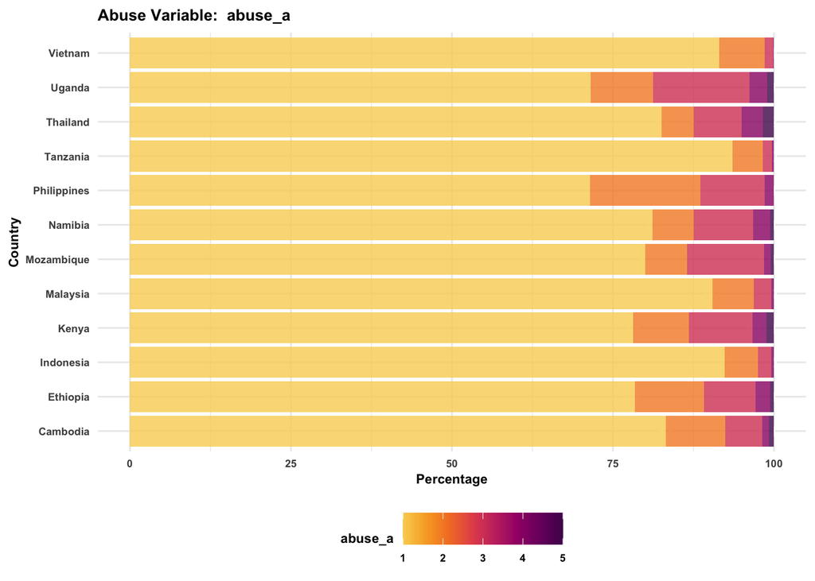

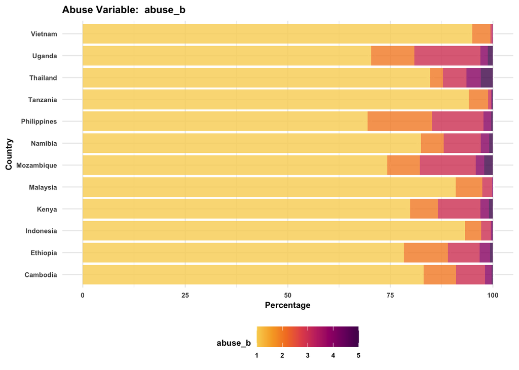

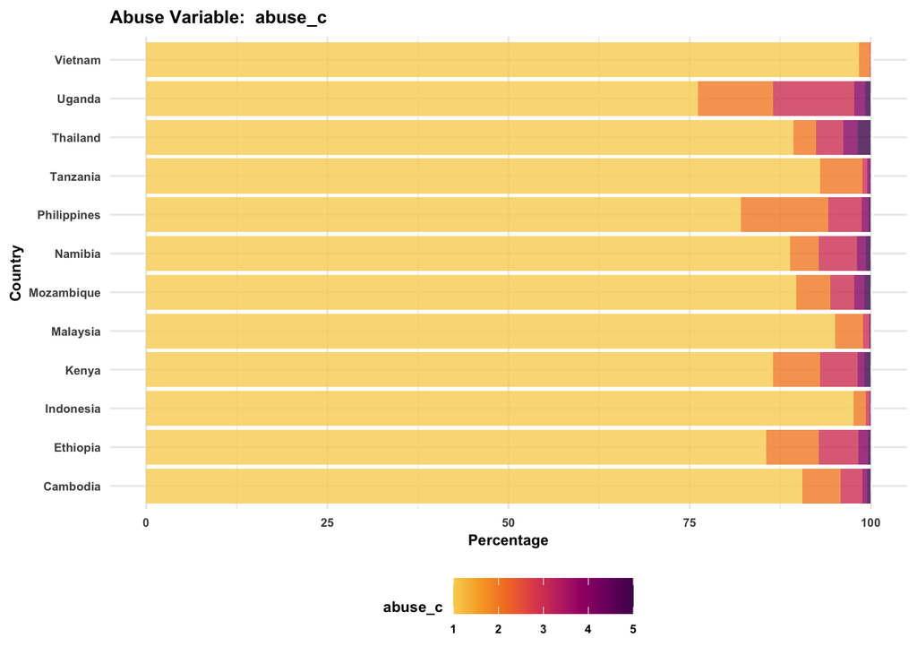

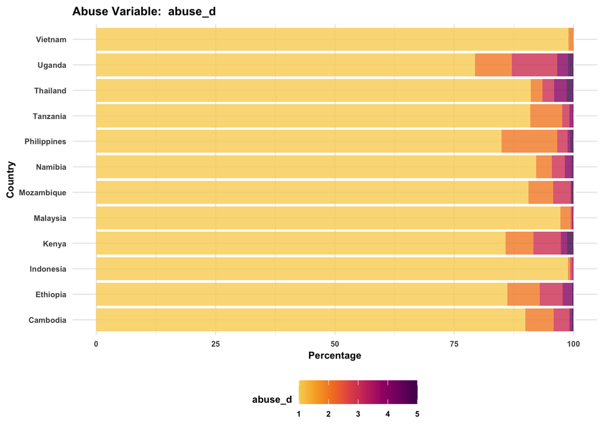

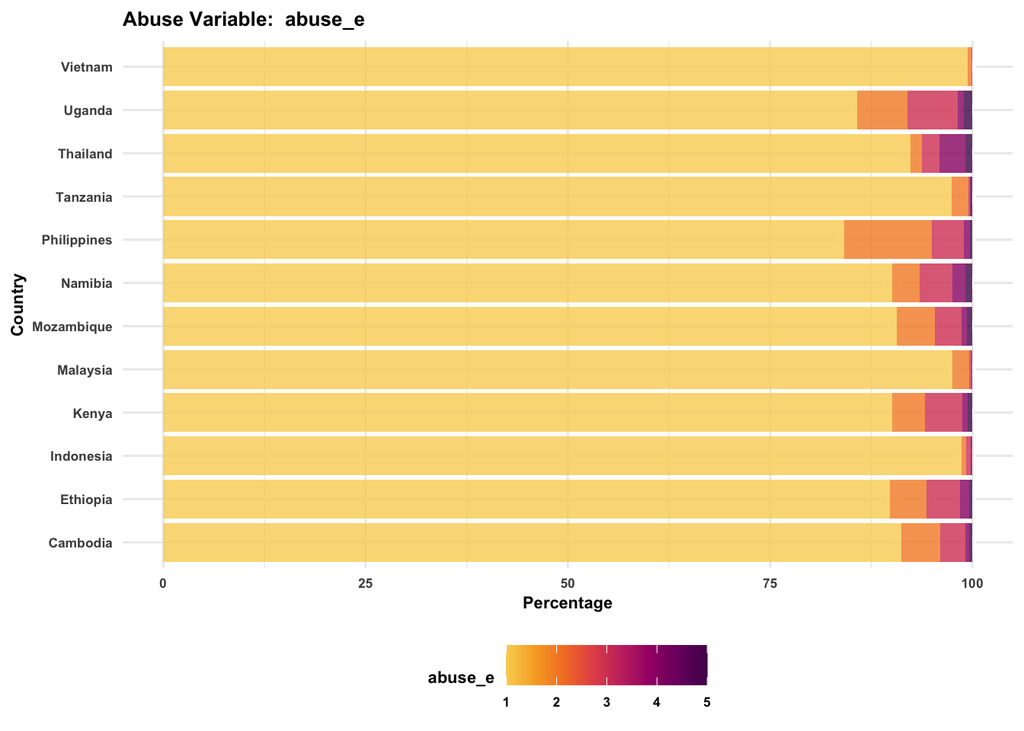

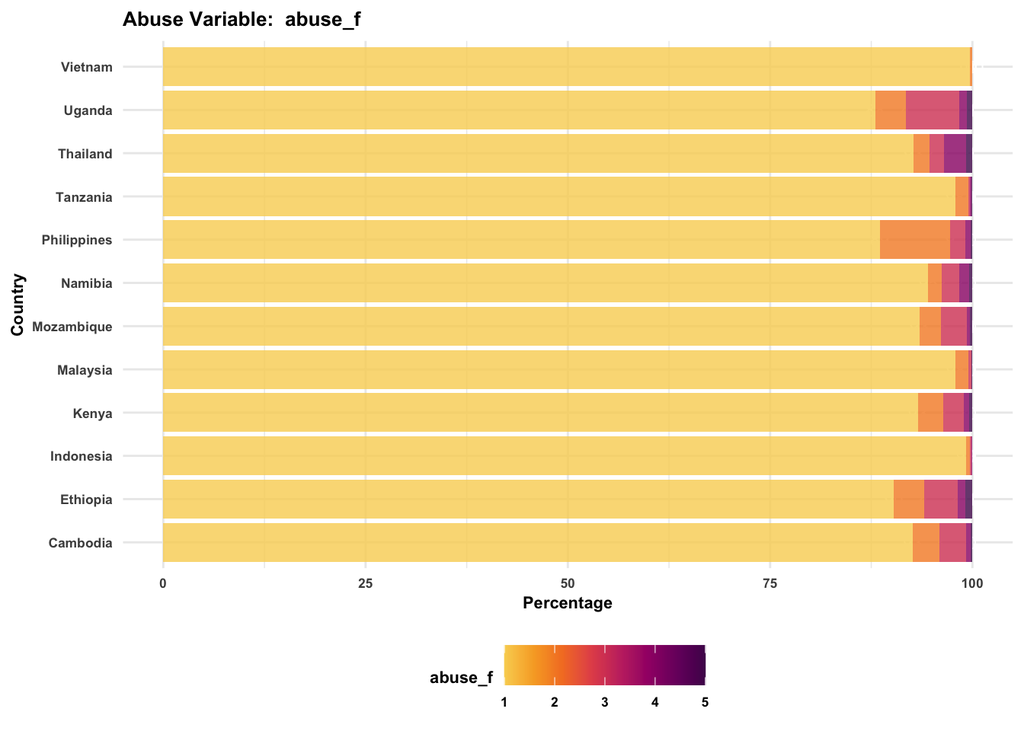

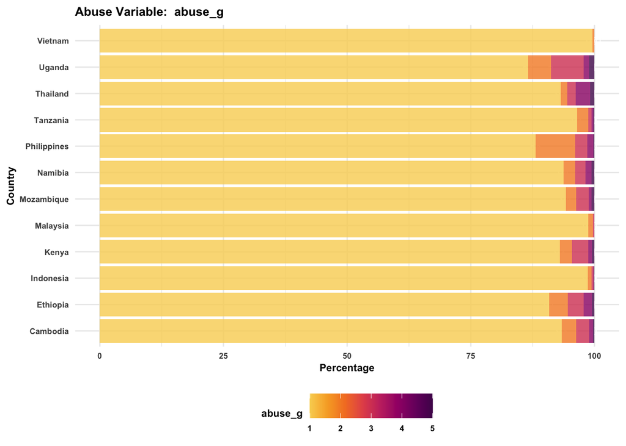

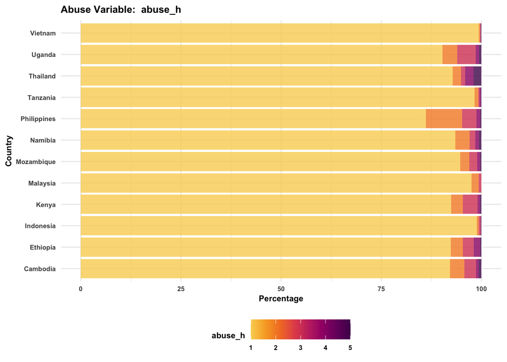

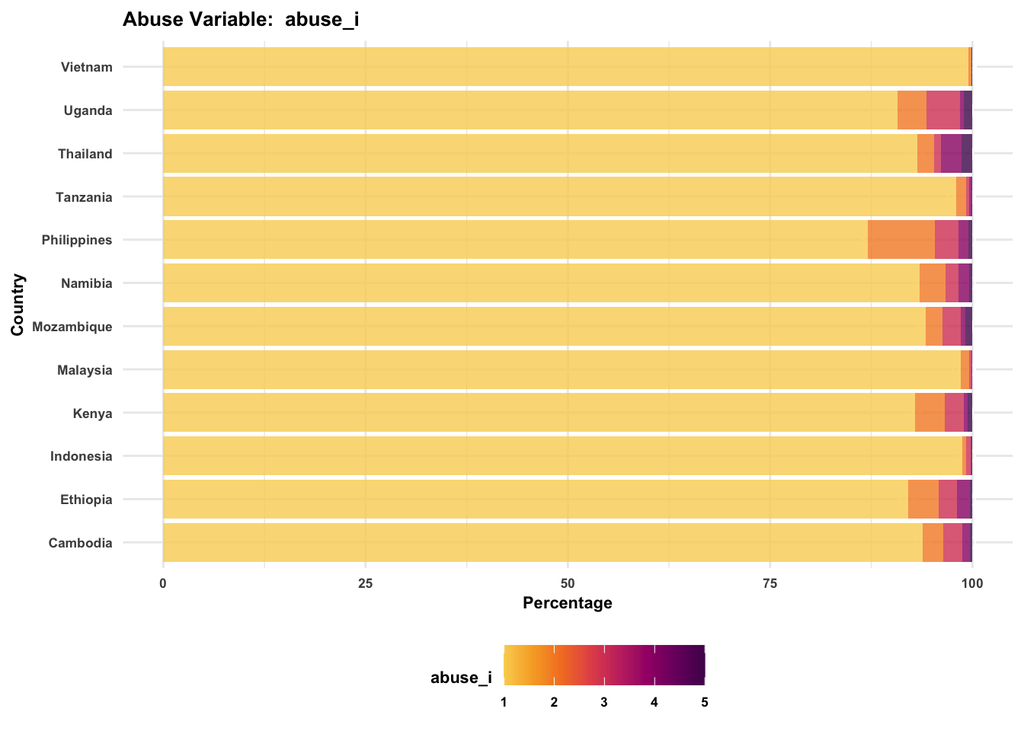

# Wrangling Independent Variables (IVs)

Micro/individual: We use a continuous measure of age (12-17 years) and categorical measure for sex (1 = girl and 0 = boy).

Macro/cultural: We extracted the various gender norms and attitudes that explored patriarchal norms regarding violence, honor, and control of girls. In the original DH survey, children were asked “Do you believe that” and presented with four statements, to which they could answer “Yes”, “No”, “I’m not sure” and “Prefer not to say”. These were then bifurcated into two separate variables – premarital sex (presex) and inequitable gender attitudes to accurately reflect progressive and regressive measure of gender norms.

Protective Factors: We also included three protective variables. The first measured whether the child had received any sex education, based on a Yes/No response to the item: “Have you received any sex education?” The second assessed digital skills for reporting harmful content, drawn from the item: “I know how to report harmful content relating to me or a group to which I belong.” Responses were recorded on a four-point Likert scale. Finally, help-seeking knowledge was assessed by asking: “Do you know where to get help if you or a friend experience sexual assault or sexual harassment?” with a Yes/No response format.

```r
recode_ivs <- function(df) {
  recoded_df <- df %>%
    mutate(
      parentmediate = rowMeans(
        select(., "pm_learn", "pm_safety", "pm_shared", "pm_bothers"),
        na.rm = TRUE
      ),
      nindex = mendecide + malerep + violence,

    )

  return(recoded_df)
}
ocsea_df <- recode_ivs(ocsea_df)
```

Check Reliability for Inequitable Gender Attitudes

```r
nindex_items <- ocsea_df  %>%
  select(mendecide, malerep, violence)

alpha_result <- psych::alpha(nindex_items)
alpha_result
```

```
Reliability analysis
Call: psych::alpha(x = nindex_items)

  raw_alpha std.alpha G6(smc) average_r S/N    ase mean   sd median_r
      0.59       0.6     0.5      0.33 1.5 0.0065 0.26 0.35     0.31

    95% confidence boundaries
         lower alpha upper
Feldt     0.57  0.59   0.6
Duhachek  0.57  0.59   0.6

 Reliability if an item is dropped:
          raw_alpha std.alpha G6(smc) average_r  S/N alpha se var.r med.r
mendecide      0.47      0.48    0.31      0.31 0.91   0.0096    NA  0.31
malerep        0.43      0.44    0.28      0.28 0.79   0.0103    NA  0.28
violence       0.55      0.57    0.40      0.40 1.31   0.0081    NA  0.40

 Item statistics
             n raw.r std.r r.cor r.drop mean   sd
mendecide 8718  0.74  0.75  0.55   0.41 0.18 0.38
malerep   8902  0.80  0.77  0.58   0.43 0.31 0.46
violence  9619  0.76  0.71  0.46   0.35 0.26 0.44

Non missing response frequency for each item
             0    1 miss
mendecide 0.82 0.18 0.27
malerep   0.69 0.31 0.25
violence  0.74 0.26 0.19
```

# Measurement of Technology-Facilitated CSEA

Following the pre-reg, we transformed the likert scale into a binary variable to estimate if the child was subjected to technology-facilitated CSEA in any form/frequency.

0. No instance of experience technology-facilitated CSEA
1. Any instance of technology-facilitated CSEA (‘Rarely’, ‘Sometimes’, ‘Often’, and ‘Very Often’)

```r
binarise_variables <- function(df, cols = abuse_all) {
  return(df %>%
    mutate(across(
      all_of(cols),
      ~ case_when(
        . == 1 ~ 0,
        between(., 2, 5) ~ 1
      )
    )))
}
ocsea_df <- binarise_variables(ocsea_df)
```

This section provides detailed operationalization of the three CSEA prevalence indicators used in this study. All measures are derived from survey items capturing nine distinct forms of child sexual exploitation and abuse (CSEA), with children indicating the context in which each incident occurred (social media, online game, in person, or other). Children were asked whether they had experienced each of the following nine forms of CSEA (Supplementary Figures 2-9). For each endorsed item, children indicated where the incident occurred using binary flags: social media, online game, in person, or some other way. Response options also included “don’t know” and “prefer not to say.”

**Primary measure**: We now create a dichotomous variable, victim, which measures whether a respondent has experienced at least one type of technology-facilitated CSEA and whether it occurred online. Adolescents who had experienced any form of technology-facilitated CSEA either on social media or in online game were coded 1. We assigned 0 to those children who had either not experienced any technology-facilitated CSEA or had only experienced non-online abuse. This approach therefore left out children who experienced technology-facilitated CSEA in-person or in some other way and allows us to take a conservative estimate of all instance of technology-facilitated CSEA that occurred exclusively online. This variable is used in subsequent models to estimate the prevalence and predictors of online-only CSEA exposure to maintain analytical specificity.

```r
compute_victim <- function(df) {
  return(df %>%
    mutate(
      victim = case_when(
        (abuse_a == 1 & (socialmedia_a == 1 | onlinegame_a == 1)) ~ 1,
        (abuse_b == 1 & (socialmedia_b == 1 | onlinegame_b == 1)) ~ 1,
        (abuse_c == 1 & (socialmedia_c == 1 | onlinegame_c == 1)) ~ 1,
        (abuse_d == 1 & (socialmedia_d == 1 | onlinegame_d == 1)) ~ 1,
        (abuse_e == 1 & (socialmedia_e == 1 | onlinegame_e == 1)) ~ 1,
        (abuse_f == 1 & (socialmedia_f == 1 | onlinegame_f == 1)) ~ 1,
        (abuse_g == 1 & (socialmedia_g == 1 | onlinegame_g == 1)) ~ 1,
        (abuse_h == 1 & (socialmedia_h == 1 | onlinegame_h == 1)) ~ 1,
        (abuse_i == 1 & (socialmedia_i == 1 | onlinegame_i == 1)) ~ 1,
        TRUE ~ 0
      )
    ))
}
ocsea_df <- compute_victim(ocsea_df)
table(ocsea_df$victim)
```

```
   0    1
9845 2067
```

**Broader CSEA** To capture the overall burden of child sexual exploitation and abuse, we constructed victim_all, which takes the value 1 if a respondent reported experiencing any of the nine CSEA items, regardless of whether the incident occurred online or offline. This measure represents a comprehensive indicator of any form of CSEA exposure, including in-person or other non-digital experiences.

```r
compute_victim2 <- function(df) {
  df %>%
    mutate(victim_all = as.integer(if_any(starts_with("abuse_"), ~ .x == 1)))
}

ocsea_df <- compute_victim2(ocsea_df)
table(ocsea_df$victim_all)
```

```
   0    1
7619 3564
```

**Inferred Technology-Facilitated CSEA**: We also constructed an inferred-technology-Facilitated CSEA indicator. Items that are intrinsically online were coded as 1 without any platform check: abuse_b (“sent me sexual images I did not want”), abuse_e (“asked for a photo/video showing my private parts”), abuse_f (“offered money/gifts in return for sexual images/videos”), and abuse_h (“shared sexual images of me without my consent”). Items that could occur either online or offline were coded as 1 only when an explicit online context was present. Specifically, abuse_a, abuse_c, abuse_d, abuse_g, and abuse_i required a platform flag—socialmedia_x == 1 or onlinegame_x == 1 for the corresponding item (for abuse_c, the online context is taken from the c platform flags as in the instrument: socialmedia_c == 1 or onlinegame_c == 1). All remaining cases were coded 0.

[output not shown]

## Technology-Facilitated CSEA Opertionalisations

Survey-weighted prevalence of technology-facilitated CSEA operationalisations by country (weighted N)

```r
svy_overall <- survey::svydesign(id = ~1, weights = ~wgt_scaled, data = ocsea_df)

victim_measures <-
svy_overall %>%
 tbl_svysummary(
    by = COUNTRY,
    include = c(victim_implied, victim, victim_all)
  ) %>%
  add_overall()
victim_measures
```

| **Characteristic** | **Overall** N = 11,912<sup>1</sup> | **Cambodia** N = 992<sup>1</sup> | **Ethiopia** N = 1,000<sup>1</sup> | **Indonesia** N = 995<sup>1</sup> | **Kenya** N = 1,014<sup>1</sup> | **Malaysia** N = 995<sup>1</sup> | **Mozambique** N = 999<sup>1</sup> | **Namibia** N = 994<sup>1</sup> | **Philippines** N = 950<sup>1</sup> | **Tanzania** N = 996<sup>1</sup> | **Thailand** N = 967<sup>1</sup> | **Uganda** N = 1,016<sup>1</sup> | **Vietnam** N = 994<sup>1</sup> |
| --- | --- | --- | --- | --- | --- | --- | --- | --- | --- | --- | --- | --- | --- |
| victim_implied | 2,761 (23%) | 239 (24%) | 267 (27%) | 93 (9.3%) | 283 (28%) | 126 (13%) | 353 (35%) | 242 (24%) | 393 (41%) | 95 (9.6%) | 206 (21%) | 389 (38%) | 75 (7.6%) |
| victim | 2,025 (17%) | 145 (15%) | 186 (19%) | 66 (6.6%) | 220 (22%) | 102 (10%) | 258 (26%) | 198 (20%) | 271 (29%) | 77 (7.7%) | 164 (17%) | 281 (28%) | 54 (5.5%) |
| victim_all | 3,477 (31%) | 287 (33%) | 355 (40%) | 122 (13%) | 370 (38%) | 151 (16%) | 435 (46%) | 273 (28%) | 458 (52%) | 144 (16%) | 245 (26%) | 514 (52%) | 123 (13%) |
| Unknown | 728 | 115 | 115 | 61 | 39 | 50 | 61 | 26 | 73 | 68 | 38 | 33 | 50 |

<sup>1</sup> n (%)

## Technology-facilitated CSEA Overall

```r
# weighted sum of victims
weighted_victim <- sum(ocsea_df$victim * ocsea_df$wgt_scaled, na.rm = TRUE)
weighted_victim
```

```
[1] 2024.65
```

```r
# sample size
total_n <- ocsea_df %>%
  summarise(total_n = n()) %>%
  pull(total_n)
total_n
```

```
[1] 11912
```

```r
#compute weighted sum
compute_percentage <- function(weighted_sum) {
  total_weights <- sum(ocsea_df$wgt_scaled, na.rm = TRUE)
  percentage <- (weighted_sum / total_weights) * 100
  return(round(percentage))
}

# percentage for each category
percentage_overall <- compute_percentage(
  sum(ocsea_df$victim * ocsea_df$wgt_scaled,
      na.rm = TRUE)
)
# final percentages
print(paste("Overall: ",  percentage_overall, "%"))
```

```
[1] "Overall:  17 %"
```

```r
percentage_overall
```

```
[1] 17
```

```r
# validating again
svy <- ocsea_df %>% as_survey_design(weights = wgt_scaled)

overall_prev <- svy %>%
  summarise(p = survey_mean(victim, vartype = "ci", na.rm = TRUE)) %>%
  mutate(
    pct     = 100 * p,
    pct_low = 100 * p_low,
    pct_upp = 100 * p_upp
  )

cat(sprintf("Tech-facilitated CSEA: %.1f%% [%.1f–%.1f]\n",
            overall_prev$pct, overall_prev$pct_low, overall_prev$pct_upp))
```

```
Tech-facilitated CSEA: 17.0% [16.2–17.8]
```

Labels for calculating prevelenece estimates

```r
# mutating abuse_wise
ocsea_df <- ocsea_df %>%
  mutate(
    abuse_a_online = if_else(abuse_a == 1 & (socialmedia_a == 1 | onlinegame_a == 1), 1L, 0L, missing = 0L),
    abuse_b_online = if_else(abuse_b == 1 & (socialmedia_b == 1 | onlinegame_b == 1), 1L, 0L, missing = 0L),
    abuse_c_online = if_else(abuse_c == 1 & (socialmedia_c == 1 | onlinegame_c == 1), 1L, 0L, missing = 0L),
    abuse_d_online = if_else(abuse_d == 1 & (socialmedia_d == 1 | onlinegame_d == 1), 1L, 0L, missing = 0L),
    abuse_e_online = if_else(abuse_e == 1 & (socialmedia_e == 1 | onlinegame_e == 1), 1L, 0L, missing = 0L),
    abuse_f_online = if_else(abuse_f == 1 & (socialmedia_f == 1 | onlinegame_f == 1), 1L, 0L, missing = 0L),
    abuse_g_online = if_else(abuse_g == 1 & (socialmedia_g == 1 | onlinegame_g == 1), 1L, 0L, missing = 0L),
    abuse_h_online = if_else(abuse_h == 1 & (socialmedia_h == 1 | onlinegame_h == 1), 1L, 0L, missing = 0L),
    abuse_i_online = if_else(abuse_i == 1 & (socialmedia_i == 1 | onlinegame_i == 1), 1L, 0L, missing = 0L)
  )

svy_overall <- survey::svydesign(id = ~1, weights = ~wgt_scaled, data = ocsea_df)

# variable lists
abuse_vars_online <- paste0("abuse_", letters[1:9], "_online")
abuse_vars_overall <- paste0("abuse_", letters[1:9])

# harm labels
abuse_labels <- c(
  abuse_a = "Unwanted sexual comments",
  abuse_b = "Sent unwanted sexual images",
  abuse_c = "Asked to talk about sex/acts",
  abuse_d = "Asked to do something sexual",
  abuse_e = "Asked for intimate photos/videos",
  abuse_f = "Offered money/gifts for images",
  abuse_g = "Offered money/gifts for in-person acts",
  abuse_h = "Shared sexual images without consent",
  abuse_i = "Threatened/blackmailed for sex"
)
names(abuse_labels) <- abuse_vars_overall
```

## Gender-Specific Prevalence Estimates

We calculate technology-facilitated CSEA prevalence separately for boys and girls using survey weights and confidence intervals.

```r
# sex diff
sex_prevalence <- ocsea_df %>%
  as_survey_design(weights = wgt_scaled) %>%
  group_by(sex) %>%
  summarise(
    n_unweighted       = unweighted(n()),
    victims_unweighted = unweighted(sum(victim == 1, na.rm = TRUE)),
    victims_weighted   = survey_total(as.numeric(victim == 1), na.rm = TRUE),
    prevalence         = survey_mean(as.numeric(victim == 1), vartype = "ci", na.rm = TRUE)
  ) %>%
  transmute(
    sex,
    n_unweighted,
    victims_unweighted,
    victims_weighted,
    `Prevalence (%)` = 100 * prevalence,
    `Lower CI`       = 100 * prevalence_low,
    `Upper CI`       = 100 * prevalence_upp
  )

kable(sex_prevalence, format = "html", escape = TRUE)
```

Descriptive prevalence by sex

| sex | n_unweighted | victims_unweighted | victims_weighted | Prevalence (%) | Lower CI | Upper CI |
| --- | --- | --- | --- | --- | --- | --- |
| Boy | 6132 | 1085 | 1025.5750 | 16.96876 | 15.90889 | 18.02863 |
| Girl | 5780 | 982 | 999.0746 | 17.02610 | 15.91536 | 18.13684 |

## Age-Specific Prevalence Estimates

```r
#age diff
age_prevalence <- ocsea_df %>%
  as_survey_design(weights = wgt_scaled) %>%
  group_by(age) %>%
  summarise(
    n_unweighted       = unweighted(n()),
    victims_unweighted = unweighted(sum(victim == 1, na.rm = TRUE)),
    victims_weighted   = survey_total(as.numeric(victim == 1), na.rm = TRUE),
    prev               = survey_mean(as.numeric(victim == 1), vartype = "ci", na.rm = TRUE)
  ) %>%
  mutate(across(c(prev, prev_low, prev_upp), ~ . * 100)) %>%
  ungroup()

kable(age_prevalence , format = "html", escape = TRUE)
```

Technology-facilitated CSEA prevalence by age

| age | n_unweighted | victims_unweighted | victims_weighted | victims_weighted_se | prev | prev_low | prev_upp |
| --- | --- | --- | --- | --- | --- | --- | --- |
| 12 | 1474 | 151 | 161.0420 | 14.85501 | 11.40535 | 9.468255 | 13.34245 |
| 13 | 1569 | 165 | 190.4085 | 16.81152 | 11.20198 | 9.372885 | 13.03107 |
| 14 | 1768 | 244 | 269.4337 | 19.28370 | 14.20981 | 12.351152 | 16.06848 |
| 15 | 1968 | 338 | 365.1689 | 21.98957 | 17.74536 | 15.830256 | 19.66047 |
| 16 | 2130 | 444 | 480.4595 | 25.28925 | 20.79140 | 18.853316 | 22.72948 |
| 17 | 3003 | 725 | 558.1369 | 23.40404 | 22.01512 | 20.353470 | 23.67677 |

## Urban-rural-Specific Prevalence Estimates

```r
# urban rural diff
urban_rural <- ocsea_df %>%
  as_survey_design(weights = wgt_scaled) %>%
  group_by(urbanrural) %>%
  summarise(
    n_unweighted       = unweighted(n()),
    victims_unweighted = unweighted(sum(victim == 1, na.rm = TRUE)),
    victims_weighted   = survey_total(as.numeric(victim == 1), na.rm = TRUE),
    prev               = survey_mean(as.numeric(victim == 1), vartype = "ci", na.rm = TRUE)
  ) %>%
  mutate(across(c(prev, prev_low, prev_upp), ~ . * 100)) %>%
  ungroup()

kable(urban_rural, format = "html", escape = TRUE)
```

Technology-facilitated CSEA prevalence by urbanrural

| urbanrural | n_unweighted | victims_unweighted | victims_weighted | victims_weighted_se | prev | prev_low | prev_upp |
| --- | --- | --- | --- | --- | --- | --- | --- |
| Peri urban | 1153 | 209 | 213.1113 | 16.83122 | 18.10606 | 15.54454 | 20.66758 |
| Rural | 6787 | 1120 | 1048.9417 | 34.39649 | 15.92739 | 14.95121 | 16.90356 |
| Urban | 3972 | 738 | 762.5965 | 31.66419 | 18.38020 | 16.99555 | 19.76485 |

## By Country (Online)

```r
# unweighted and weighted counts
n_counts <- ocsea_df %>%
  group_by(COUNTRY) %>%
  summarise(
    n_unweighted  = n(),
    n_victims_unw = sum(victim == 1, na.rm = TRUE),
    n_weighted    = round(sum(wgt_scaled, na.rm = TRUE)),
    n_victims_w   = round(sum(victim * wgt_scaled, na.rm = TRUE))
  )

# weighted prevalence
prev_country <- ocsea_df %>%
  as_survey_design(weights = wgt_scaled) %>%
  group_by(COUNTRY) %>%
  summarise(
    prev = survey_mean(as.numeric(victim == 1), vartype = "ci", na.rm = TRUE)
  ) %>%
  mutate(
    Prevalence = prev * 100,
    Lower      = prev_low * 100,
    Upper      = prev_upp * 100
  ) %>%
  left_join(n_counts, by = "COUNTRY") %>%
  mutate(
    `n/N (unweighted)` = paste0(
      format(n_victims_unw, big.mark = ","), "/",
      format(n_unweighted,  big.mark = ",")
    ),
    `n/N (weighted)` = paste0(
      format(n_victims_w, big.mark = ","), "/",
      format(n_weighted,  big.mark = ",")
    )
  ) %>%
  arrange(desc(Prevalence))

country_results <- prev_country %>%
  select(
    Country              = COUNTRY,
    `n/N (unweighted)`   = `n/N (unweighted)`,
    `n/N (weighted)`     = `n/N (weighted)`,
    `Prevalence (%)`     = Prevalence,
    `Lower CI`           = Lower,
    `Upper CI`           = Upper
  )

kable(
  country_results,
  digits    = 1,
  row.names = FALSE,
  caption   = "Online CSEA prevalence by country"
)
```

Online CSEA prevalence by country

| Country | n/N (unweighted) | n/N (weighted) | Prevalence (%) | Lower CI | Upper CI |
| --- | --- | --- | --- | --- | --- |
| Philippines | 269/ 950 | 271/ 950 | 28.6 | 25.3 | 31.9 |
| Uganda | 311/1,016 | 281/1,016 | 27.7 | 24.6 | 30.8 |
| Mozambique | 231/ 999 | 258/ 999 | 25.9 | 22.6 | 29.1 |
| Kenya | 230/1,014 | 220/1,014 | 21.7 | 19.0 | 24.4 |
| Namibia | 225/ 994 | 198/ 994 | 20.0 | 17.1 | 22.8 |
| Ethiopia | 195/1,000 | 186/1,000 | 18.6 | 15.7 | 21.5 |
| Thailand | 157/ 967 | 164/ 967 | 17.0 | 14.3 | 19.6 |
| Cambodia | 137/ 992 | 145/ 992 | 14.7 | 12.2 | 17.1 |
| Malaysia | 109/ 995 | 102/ 995 | 10.2 | 8.1 | 12.4 |
| Tanzania | 88/ 996 | 77/ 996 | 7.7 | 6.0 | 9.5 |
| Indonesia | 66/ 995 | 66/ 995 | 6.6 | 5.0 | 8.3 |
| Vietnam | 49/ 994 | 54/ 994 | 5.5 | 3.7 | 7.3 |

## By Country (All CSEA)

```r
n_counts_all <- ocsea_df %>%
  group_by(COUNTRY) %>%
  summarise(
    n_unweighted  = n(),
    n_victims_unw = sum(victim_all == 1, na.rm = TRUE),
    n_weighted    = round(sum(wgt_scaled, na.rm = TRUE)),
    n_victims_w   = round(sum(victim_all * wgt_scaled, na.rm = TRUE))
  )

prev_country_all <- ocsea_df %>%
  as_survey_design(weights = wgt_scaled) %>%
  group_by(COUNTRY) %>%
  summarise(
    prev = survey_mean(as.numeric(victim_all == 1), vartype = "ci", na.rm = TRUE)
  ) %>%
  mutate(
    Prevalence = prev * 100,
    Lower      = prev_low * 100,
    Upper      = prev_upp * 100
  ) %>%
  left_join(n_counts_all, by = "COUNTRY") %>%
  mutate(
    `n/N (unweighted)` = paste0(
      format(n_victims_unw, big.mark = ","), "/",
      format(n_unweighted,  big.mark = ",")
    ),
    `n/N (weighted)` = paste0(
      format(n_victims_w, big.mark = ","), "/",
      format(n_weighted,  big.mark = ",")
    )
  ) %>%
  arrange(desc(Prevalence))

kable(
  prev_country_all %>%
    select(
      Country              = COUNTRY,
      `n/N (unweighted)`   = `n/N (unweighted)`,
      `n/N (weighted)`     = `n/N (weighted)`,
      `Prevalence (%)`     = Prevalence,
      `Lower CI`           = Lower,
      `Upper CI`           = Upper
    ),
  digits    = 1,
  row.names = FALSE,
  caption   = "All CSEA prevalence by country"
)
```

All CSEA prevalence by country

| Country | n/N (unweighted) | n/N (weighted) | Prevalence (%) | Lower CI | Upper CI |
| --- | --- | --- | --- | --- | --- |
| Uganda | 549/1,016 | 514/1,016 | 52.3 | 48.7 | 55.9 |
| Philippines | 449/ 950 | 458/ 950 | 52.2 | 48.4 | 55.9 |
| Mozambique | 423/ 999 | 435/ 999 | 46.4 | 42.6 | 50.1 |
| Ethiopia | 374/1,000 | 355/1,000 | 40.2 | 36.3 | 44.0 |
| Kenya | 379/1,014 | 370/1,014 | 37.9 | 34.7 | 41.2 |
| Cambodia | 288/ 992 | 287/ 992 | 32.7 | 29.3 | 36.1 |
| Namibia | 303/ 994 | 273/ 994 | 28.2 | 24.9 | 31.5 |
| Thailand | 240/ 967 | 245/ 967 | 26.4 | 23.3 | 29.5 |
| Malaysia | 158/ 995 | 151/ 995 | 16.0 | 13.3 | 18.7 |
| Tanzania | 159/ 996 | 144/ 996 | 15.5 | 13.0 | 18.0 |
| Indonesia | 125/ 995 | 122/ 995 | 13.1 | 10.8 | 15.5 |
| Vietnam | 117/ 994 | 123/ 994 | 13.0 | 10.4 | 15.6 |

## By Type (Online)

```r
# map online variable name to label
get_harm_label <- function(online_var) {
  base_var <- sub("_online$", "", online_var)
  unname(abuse_labels[base_var])
}

# unweighted and weighted counts by type
n_counts_type <- map_dfr(abuse_vars_online, function(var) {
  tibble(
    Type          = get_harm_label(var),
    n_unweighted  = sum(!is.na(ocsea_df[[var]])),
    n_victims_unw = sum(ocsea_df[[var]] == 1, na.rm = TRUE),
    n_weighted    = round(sum(ocsea_df$wgt_scaled, na.rm = TRUE)),
    n_victims_w   = round(sum(ocsea_df[[var]] * ocsea_df$wgt_scaled, na.rm = TRUE))
  )
}) %>%
  bind_rows(tibble(
    Type          = "Any online CSEA",
    n_unweighted  = sum(!is.na(ocsea_df$victim)),
    n_victims_unw = sum(ocsea_df$victim == 1, na.rm = TRUE),
    n_weighted    = round(sum(ocsea_df$wgt_scaled, na.rm = TRUE)),
    n_victims_w   = round(sum(ocsea_df$victim * ocsea_df$wgt_scaled, na.rm = TRUE))
  ))

online_prev <- function(by_country = FALSE) {
  des <- ocsea_df %>%
    as_survey_design(weights = wgt_scaled)

  type_res <- map_dfr(abuse_vars_online, function(var) {
    lab <- get_harm_label(var)

    if (!by_country) {
      est <- des %>%
        summarise(
          prev = survey_mean(.data[[var]], vartype = "ci", na.rm = TRUE)
        )
      tibble(
        Type       = lab,
        Prevalence = est$prev     * 100,
        Lower      = est$prev_low * 100,
        Upper      = est$prev_upp * 100
      )
    } else {
      est <- des %>%
        group_by(COUNTRY) %>%
        summarise(
          prev = survey_mean(.data[[var]], vartype = "ci", na.rm = TRUE),
          .groups = "drop"
        )
      tibble(
        Country    = as.character(est$COUNTRY),
        Type       = lab,
        Prevalence = est$prev     * 100,
        Lower      = est$prev_low * 100,
        Upper      = est$prev_upp * 100
      )
    }
  })

  if (!by_country) {
    overall_est <- des %>%
      summarise(
        prev = survey_mean(as.numeric(victim == 1), vartype = "ci", na.rm = TRUE)
      )
    overall_row <- tibble(
      Type       = "Any online CSEA",
      Prevalence = overall_est$prev     * 100,
      Lower      = overall_est$prev_low * 100,
      Upper      = overall_est$prev_upp * 100
    )
    out <- bind_rows(type_res, overall_row) %>%
      left_join(n_counts_type, by = "Type") %>%
      mutate(
        `n/N (unweighted)` = paste0(
          format(n_victims_unw, big.mark = ","), "/",
          format(n_unweighted,  big.mark = ",")
        ),
        `n/N (weighted)` = paste0(
          format(n_victims_w, big.mark = ","), "/",
          format(n_weighted,  big.mark = ",")
        )
      ) %>%
      arrange(desc(Prevalence)) %>%
      select(Type, `n/N (unweighted)`, `n/N (weighted)`, Prevalence, Lower, Upper)

  } else {
    overall_est <- des %>%
      group_by(COUNTRY) %>%
      summarise(
        prev = survey_mean(as.numeric(victim == 1), vartype = "ci", na.rm = TRUE),
        .groups = "drop"
      )
    overall_row <- tibble(
      Country    = as.character(overall_est$COUNTRY),
      Type       = "Any online CSEA",
      Prevalence = overall_est$prev     * 100,
      Lower      = overall_est$prev_low * 100,
      Upper      = overall_est$prev_upp * 100
    )
    out <- bind_rows(type_res, overall_row) %>%
      arrange(Country, desc(Prevalence)) %>%
      select(Country, Type, Prevalence, Lower, Upper)
  }
  out
}

type_results <- online_prev(by_country = FALSE)

kable(
  type_results,
  digits    = 1,
  row.names = FALSE,
  col.names = c("Type of Abuse", "n/N (unweighted)", "n/N (weighted)",
                "Prevalence (%)", "Lower CI", "Upper CI"),
  caption   = "Online CSEA prevalence by type"
)
```

Online CSEA prevalence by type

| Type of Abuse | n/N (unweighted) | n/N (weighted) | Prevalence (%) | Lower CI | Upper CI |
| --- | --- | --- | --- | --- | --- |
| Any online CSEA | 2,067/11,912 | 2,025/11,912 | 17.0 | 16.2 | 17.8 |
| Sent unwanted sexual images | 1,176/11,912 | 1,143/11,912 | 9.6 | 9.0 | 10.2 |
| Unwanted sexual comments | 901/11,912 | 889/11,912 | 7.5 | 6.9 | 8.0 |
| Asked to talk about sex/acts | 581/11,912 | 571/11,912 | 4.8 | 4.4 | 5.2 |
| Asked for intimate photos/videos | 499/11,912 | 498/11,912 | 4.2 | 3.8 | 4.6 |
| Asked to do something sexual | 472/11,912 | 462/11,912 | 3.9 | 3.5 | 4.3 |
| Shared sexual images without consent | 338/11,912 | 332/11,912 | 2.8 | 2.5 | 3.1 |
| Offered money/gifts for in-person acts | 331/11,912 | 328/11,912 | 2.8 | 2.4 | 3.1 |
| Offered money/gifts for images | 335/11,912 | 324/11,912 | 2.7 | 2.4 | 3.1 |
| Threatened/blackmailed for sex | 288/11,912 | 294/11,912 | 2.5 | 2.1 | 2.8 |

## By Type (All CSEA)

```r
type_results_all <- map_dfr(abuse_vars_overall, function(var) {
  lab <- unname(abuse_labels[var])

 est <- ocsea_df %>%
  as_survey_design(weights = wgt_scaled) %>%
    summarise(
      prev = survey_mean(.data[[var]], vartype = "ci", na.rm = TRUE)
    )

  tibble(
    Type       = lab,
    Prevalence = est$prev     * 100,
    Lower      = est$prev_low * 100,
    Upper      = est$prev_upp * 100
  )
})

overall_all <- svy_overall %>%
  as_survey_design(weights = wgt_scaled) %>%
  summarise(
    prev = survey_mean(as.numeric(victim_all == 1), vartype = "ci", na.rm = TRUE)
  )

type_results_all <- type_results_all %>%
  bind_rows(
    tibble(
      Type       = "Any CSEA (any context)",
      Prevalence = overall_all$prev     * 100,
      Lower      = overall_all$prev_low * 100,
      Upper      = overall_all$prev_upp * 100
    )
  ) %>%
  arrange(desc(Prevalence))

kable(
  type_results_all,
  digits   = 1,
  row.names = FALSE,
  col.names = c("Type of Abuse", "Prevalence (%)", "Lower CI", "Upper CI"),
  caption  = "CSEA prevalence by type (any context)"
)
```

CSEA prevalence by type (any context)

| Type of Abuse | Prevalence (%) | Lower CI | Upper CI |
| --- | --- | --- | --- |
| Any CSEA (any context) | 31.1 | 30.1 | 32.1 |
| Unwanted sexual comments | 16.7 | 16.0 | 17.5 |
| Sent unwanted sexual images | 16.6 | 15.8 | 17.4 |
| Asked to talk about sex/acts | 10.2 | 9.6 | 10.8 |
| Asked to do something sexual | 9.3 | 8.7 | 9.9 |
| Asked for intimate photos/videos | 7.8 | 7.2 | 8.3 |
| Offered money/gifts for in-person acts | 5.8 | 5.4 | 6.3 |
| Offered money/gifts for images | 5.7 | 5.2 | 6.2 |
| Shared sexual images without consent | 5.7 | 5.2 | 6.1 |
| Threatened/blackmailed for sex | 5.4 | 5.0 | 5.9 |

## By Type and Country (Online CSEA)

```r
# counts by country and type
n_counts_type_country <- map_dfr(abuse_vars_online, function(var) {
  ocsea_df %>%
    group_by(COUNTRY) %>%
    summarise(
      Type          = get_harm_label(var),
      Denominator   = sum(!is.na(.data[[var]])),
      Victims_unw   = sum(.data[[var]] == 1, na.rm = TRUE),
      Victims_w     = round(sum(.data[[var]] * wgt_scaled, na.rm = TRUE))
    )
}) %>%
  bind_rows(
    ocsea_df %>%
      group_by(COUNTRY) %>%
      summarise(
        Type        = "Any online CSEA",
        Denominator = sum(!is.na(victim)),
        Victims_unw = sum(victim == 1, na.rm = TRUE),
        Victims_w   = round(sum(victim * wgt_scaled, na.rm = TRUE))
      )
  )

# join into results
type_country_results <- online_prev(by_country = TRUE) %>%
  left_join(n_counts_type_country, by = c("Country" = "COUNTRY", "Type")) %>%
  select(Country, Type, Denominator, Victims_unw, Victims_w, Prevalence, Lower, Upper)

kable(
  type_country_results,
  digits    = 1,
  row.names = FALSE,
  col.names = c("Country", "Type of Abuse", "Denominator (N)",
                "Victims (unweighted)", "Victims (weighted)",
                "Prevalence (%)", "Lower CI", "Upper CI"),
  caption   = "Online CSEA prevalence by type and country"
)
```

Online CSEA prevalence by type and country

| Country | Type of Abuse | Denominator (N) | Victims (unweighted) | Victims (weighted) | Prevalence (%) | Lower CI | Upper CI |
| --- | --- | --- | --- | --- | --- | --- | --- |
| Cambodia | Any online CSEA | 992 | 137 | 145 | 14.7 | 12.2 | 17.1 |
| Cambodia | Sent unwanted sexual images | 992 | 69 | 74 | 7.4 | 5.6 | 9.2 |
| Cambodia | Unwanted sexual comments | 992 | 62 | 69 | 7.0 | 5.2 | 8.8 |
| Cambodia | Asked to do something sexual | 992 | 40 | 44 | 4.4 | 3.0 | 5.8 |
| Cambodia | Asked for intimate photos/videos | 992 | 35 | 38 | 3.9 | 2.6 | 5.2 |
| Cambodia | Asked to talk about sex/acts | 992 | 28 | 31 | 3.1 | 1.9 | 4.3 |
| Cambodia | Offered money/gifts for in-person acts | 992 | 28 | 30 | 3.0 | 1.9 | 4.2 |
| Cambodia | Shared sexual images without consent | 992 | 26 | 27 | 2.8 | 1.6 | 3.9 |
| Cambodia | Threatened/blackmailed for sex | 992 | 20 | 21 | 2.1 | 1.2 | 3.1 |
| Cambodia | Offered money/gifts for images | 992 | 20 | 19 | 1.9 | 1.1 | 2.8 |
| Ethiopia | Any online CSEA | 1000 | 195 | 186 | 18.6 | 15.7 | 21.5 |
| Ethiopia | Sent unwanted sexual images | 1000 | 98 | 87 | 8.7 | 6.8 | 10.7 |
| Ethiopia | Unwanted sexual comments | 1000 | 80 | 78 | 7.8 | 5.8 | 9.7 |
| Ethiopia | Asked to talk about sex/acts | 1000 | 59 | 59 | 5.9 | 4.1 | 7.7 |
| Ethiopia | Asked to do something sexual | 1000 | 41 | 42 | 4.2 | 2.6 | 5.7 |
| Ethiopia | Asked for intimate photos/videos | 1000 | 36 | 37 | 3.7 | 2.3 | 5.2 |
| Ethiopia | Offered money/gifts for images | 1000 | 35 | 28 | 2.8 | 1.7 | 3.9 |
| Ethiopia | Offered money/gifts for in-person acts | 1000 | 29 | 25 | 2.5 | 1.4 | 3.6 |
| Ethiopia | Shared sexual images without consent | 1000 | 28 | 21 | 2.1 | 1.2 | 3.0 |
| Ethiopia | Threatened/blackmailed for sex | 1000 | 24 | 20 | 2.0 | 1.1 | 2.9 |
| Indonesia | Any online CSEA | 995 | 66 | 66 | 6.6 | 5.0 | 8.3 |
| Indonesia | Sent unwanted sexual images | 995 | 37 | 38 | 3.8 | 2.5 | 5.1 |
| Indonesia | Unwanted sexual comments | 995 | 27 | 25 | 2.5 | 1.5 | 3.5 |
| Indonesia | Asked to talk about sex/acts | 995 | 12 | 11 | 1.1 | 0.4 | 1.8 |
| Indonesia | Offered money/gifts for in-person acts | 995 | 7 | 6 | 0.6 | 0.1 | 1.1 |
| Indonesia | Asked to do something sexual | 995 | 4 | 5 | 0.5 | 0.0 | 1.0 |
| Indonesia | Threatened/blackmailed for sex | 995 | 4 | 4 | 0.4 | 0.0 | 0.9 |
| Indonesia | Asked for intimate photos/videos | 995 | 6 | 4 | 0.4 | 0.0 | 0.8 |
| Indonesia | Shared sexual images without consent | 995 | 3 | 3 | 0.3 | -0.1 | 0.7 |
| Indonesia | Offered money/gifts for images | 995 | 2 | 2 | 0.2 | -0.1 | 0.5 |

[output cut: 90 more lines]

# Technology-facilitated CSEA (weighted) Maps

### Nine Types of Technology-facilitated CSEA Measures

```r
# harm_labels same as abuse_labels
map_labels <- harm_labels

countries <- c(
  "Ethiopia", "Kenya", "Mozambique", "Namibia", "Tanzania", "Uganda",
  "Cambodia", "Indonesia", "Malaysia", "Philippines", "Thailand", "Vietnam"
)

# define the variable list
abuse_all_online <- abuse_vars_online

all_max_values <- numeric()

for (variable in abuse_all_online) {
  temp_data <- ocsea_df %>%
    group_by(COUNTRY) %>%
    summarize(
      weighted_sum = sum(get(variable) * wgt_scaled, na.rm = TRUE),
      total_responses = sum(wgt_scaled, na.rm = TRUE),
      .groups = "drop"
    ) %>%
    mutate(percentage_abuse = (weighted_sum / total_responses) * 100)

  all_max_values <- c(all_max_values, max(temp_data$percentage_abuse, na.rm = TRUE))
}

data_max <- max(all_max_values, na.rm = TRUE)
scale_max <- ceiling(data_max / 5) * 5
scale_max <- max(scale_max, 20)
```

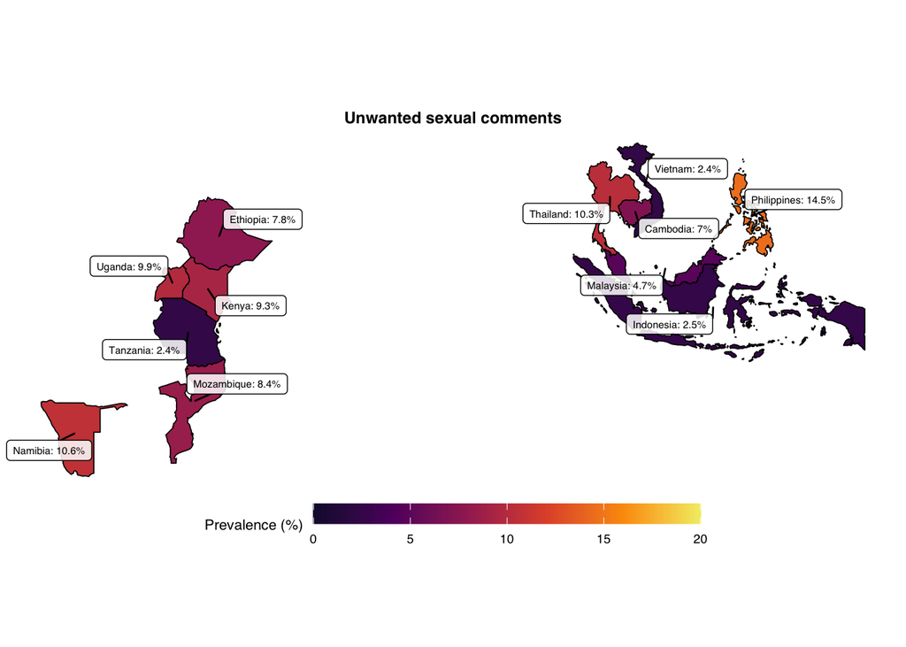

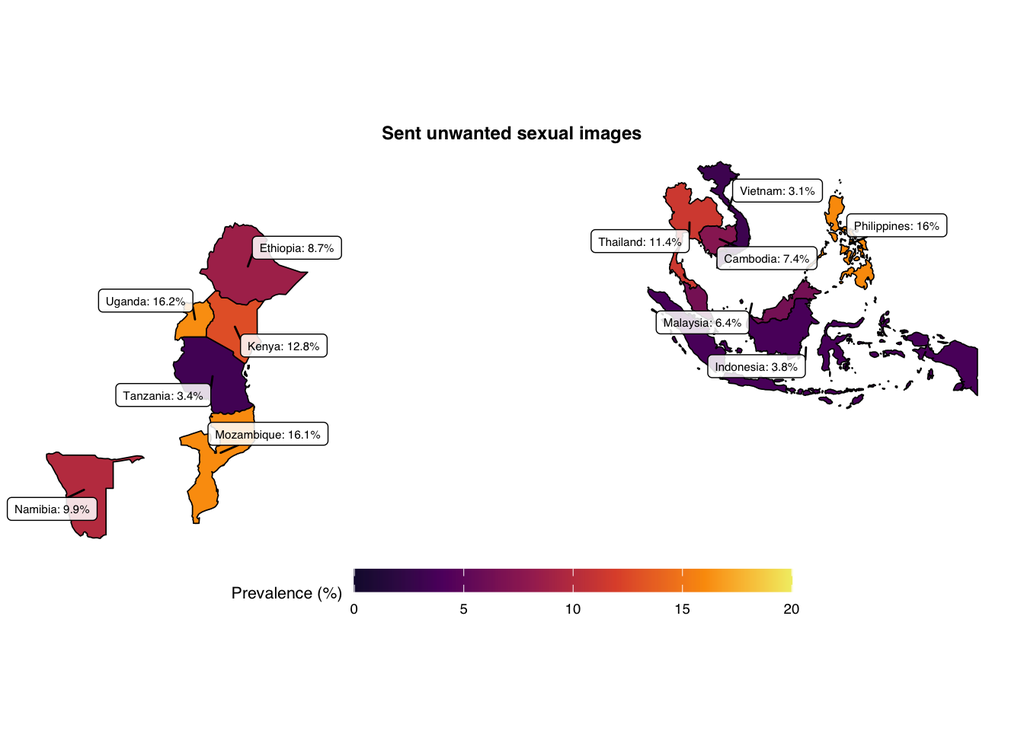

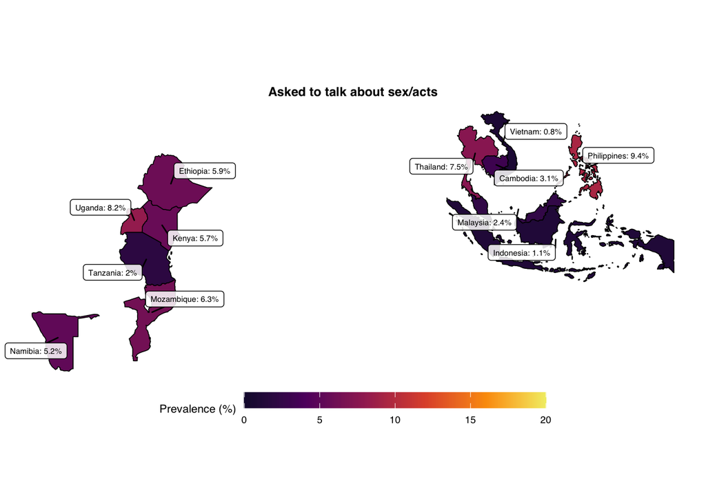

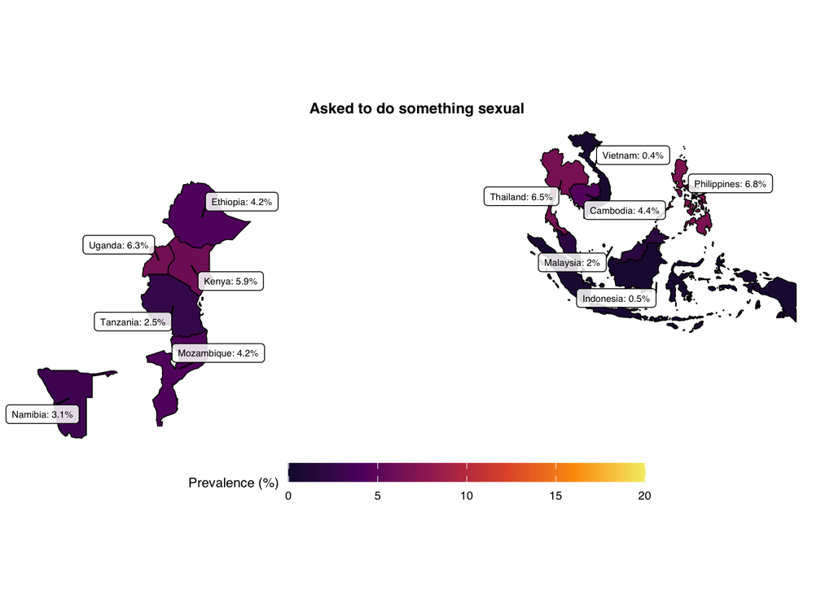

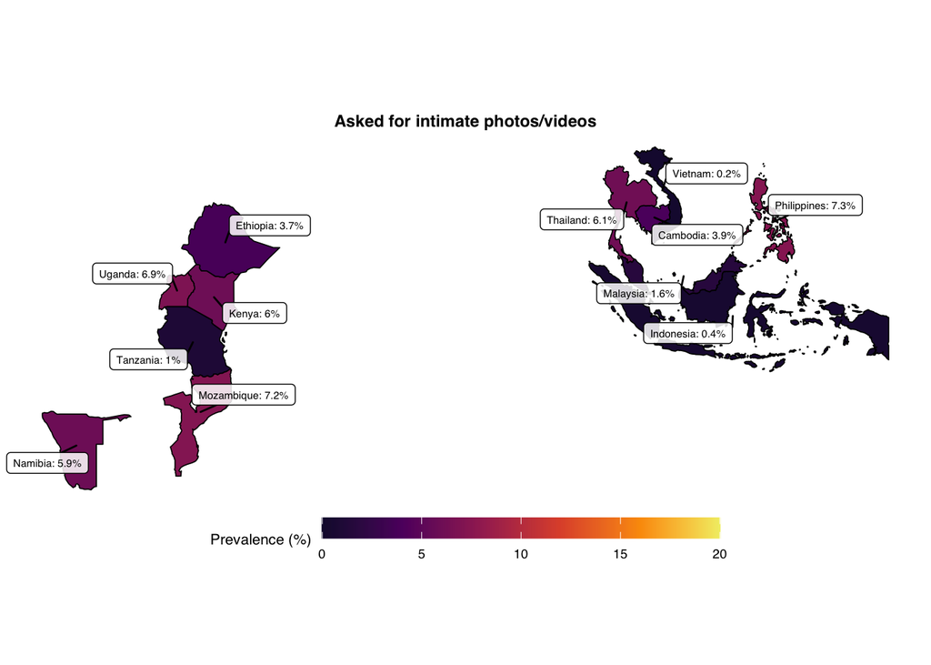

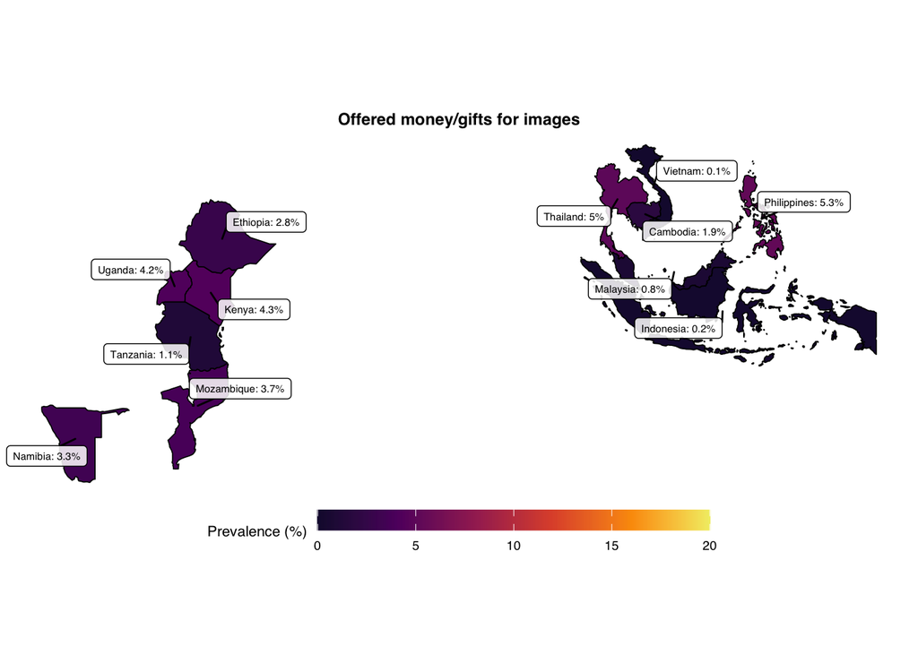

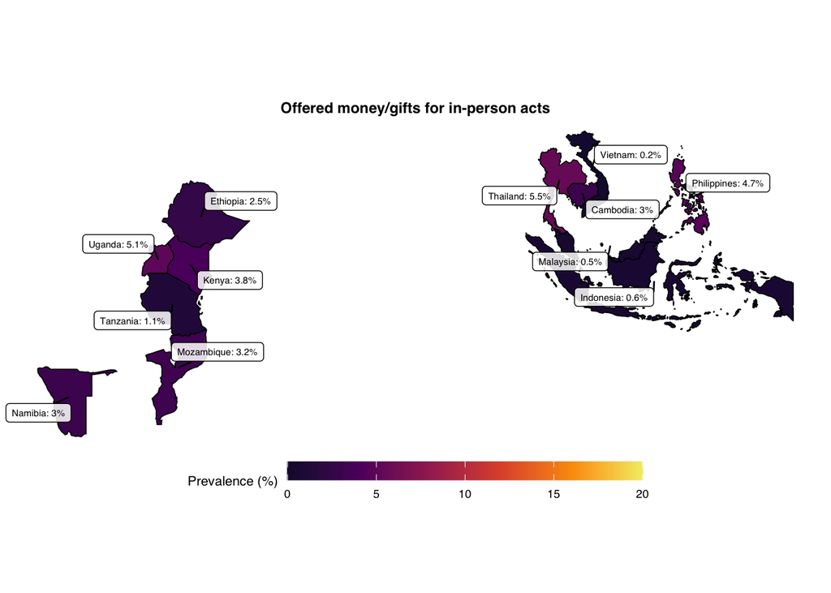

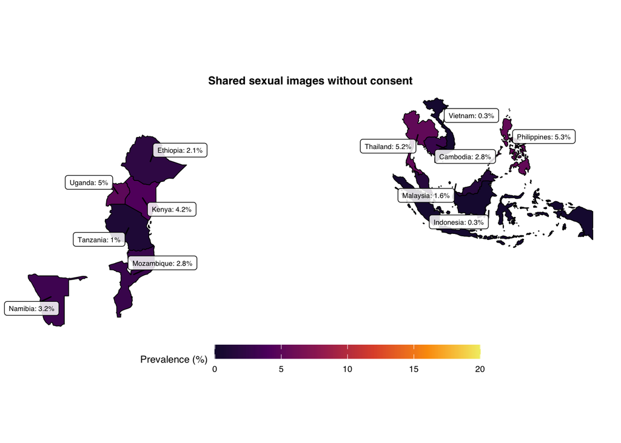

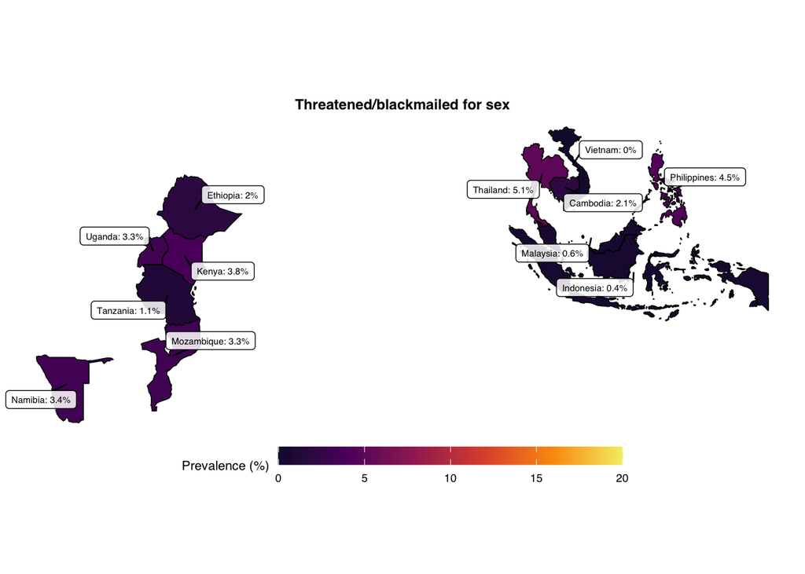

```r
make_map <- function(variable, show_legend = TRUE, scale_maximum = scale_max) {

  title <- abuse_labels[[sub("_online$", "", variable)]]

  # calculate weighted prevalence
  weighted_by_country <- ocsea_df %>%
    group_by(COUNTRY) %>%
    summarize(
      weighted_sum    = sum(get(variable) * wgt_scaled, na.rm = TRUE),
      total_responses = sum(wgt_scaled, na.rm = TRUE),
      .groups = "drop"
    ) %>%
    mutate(percentage_abuse = round((weighted_sum / total_responses) * 100, 1))

  # natural earth world map (public domain)
  world_sf <- ne_countries(scale = "medium", returnclass = "sf") %>%
    select(name, geometry) %>%
    mutate(name = case_match(name,
      "United Republic of Tanzania" ~ "Tanzania",
      "Viet Nam"                    ~ "Vietnam",
      .default = name
    ))

  # join prevalence data
  world_joined <- world_sf %>%
    left_join(weighted_by_country, by = c("name" = "COUNTRY"))

  # filter to study countries
  world_filtered <- world_joined %>%
    filter(name %in% countries)

  # centroids for labels
  centroids <- world_filtered %>%
    filter(!is.na(percentage_abuse)) %>%
    st_centroid() %>%
    mutate(
      long = st_coordinates(.)[, 1],
      lat  = st_coordinates(.)[, 2]
    ) %>%
    st_drop_geometry()

  # plot
  map_plot <- ggplot() +
    geom_sf(
      data      = world_filtered,
      aes(fill  = percentage_abuse),
      color     = "black",
      linewidth = 0.3
    ) +
    scale_fill_viridis_c(
      name   = "Prevalence (%)",
      option = "inferno",
      limits = c(0, scale_maximum),
      breaks = seq(0, scale_maximum, by = 5),
      begin  = 0.1,
      end    = 0.95,
      na.value = "grey85",
      guide  = if (show_legend) guide_colorbar(barwidth = 15, barheight = 0.8) else "none"
    ) +
    geom_label_repel(
      data    = centroids,
      aes(x   = long, y = lat,
          label = paste0(name, ": ", percentage_abuse, "%")),
      size    = 2.0,
      family  = "sans",
      fill    = alpha("white", 0.85),
      min.segment.length = 0,
      seed    = 42
    ) +
    coord_sf(datum = NA) +
    theme_void() +
    labs(title = str_wrap(title, width = 50)) +
    theme(
      plot.title       = element_text(size = 9, hjust = 0.5,
                                      face = "bold", family = "sans"),
      legend.position  = if (show_legend) "bottom" else "none",
      legend.text      = element_text(size = 7, family = "sans"),
      legend.title     = element_text(size = 8, family = "sans")
    )

  return(map_plot)
}

# generate all maps
map_plots <- list()
for (variable in abuse_all_online) {
  map_plots[[variable]] <- make_map(variable, show_legend = TRUE)
}
for (p in map_plots) {
  print(p)
}
```

## Combine Figure 1

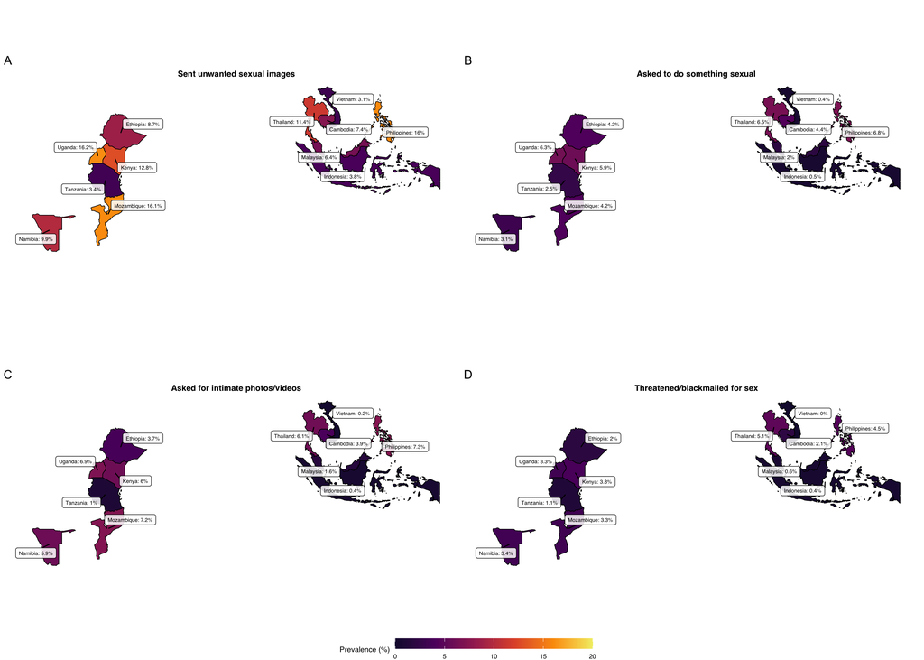

Estimated proportion of internet-using children who self-reported their experience of technology-facilitated CSEA in 2020-2021.

## Extended Data Figure 1

```r
abuse_all_online <- names(abuse_labels_online)

# country ordering by overall victim prevalence
svy_victim_nomiss <- subset(svy_overall, !is.na(victim))
country_order <- svyby(
  ~ victim,
  by      = ~ COUNTRY,
  design  = svy_victim_nomiss,
  FUN     = svymean,
  vartype = "ci"
) %>%
  as_tibble() %>%
  arrange(victim) %>%
  pull(COUNTRY)

# compute prevalence per type × country
harms_by_country <- map_dfr(abuse_all_online, function(var) {
  formula <- as.formula(paste("~", var))
  result <- svyby(formula, ~COUNTRY, design = svy_overall, svymean,
                  na.rm = TRUE, vartype = "ci")
  out <- as_tibble(result)
  names(out)[2:4] <- c("prop", "prop_low", "prop_upp")
  out$harm <- var
  out
}) %>%
  mutate(
    pct     = 100 * prop,
    pct_low = 100 * prop_low,
    pct_upp = 100 * prop_upp
  )

# compute raw counts per type × country for n<3 check
raw_counts <- map_dfr(abuse_all_online, function(var) {
  svy_overall$variables %>%
    group_by(COUNTRY) %>%
    summarise(
      n    = sum(!is.na(.data[[var]]) & .data[[var]] == 1),
      harm = var,
      .groups = "drop"
    )
})

# map harm codes to labels, set country order, join counts
extended_data <- harms_by_country %>%
  mutate(
    harm    = factor(
      harm,
      levels = names(abuse_labels_online),
      labels = unname(abuse_labels_online)
    ),
    COUNTRY = factor(COUNTRY, levels = country_order)
  ) %>%
  left_join(
    raw_counts %>%
      mutate(
        harm = factor(
          harm,
          levels = names(abuse_labels_online),
          labels = unname(abuse_labels_online)
        )
      ),
    by = c("COUNTRY", "harm")
  ) %>%
  mutate(
    show_ci = n >= 3,
    COUNTRY = factor(COUNTRY, levels = country_order)  # restore order after join
  )
```

```
`height` was translated to `width`.
```

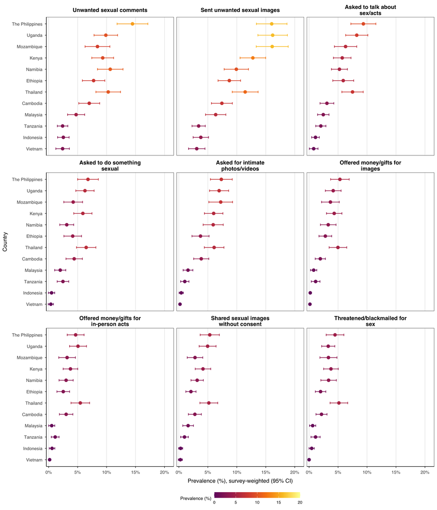

Survey-weighted prevalence of nine technology-facilitated CSEA harms by country with 95% design-based confidence intervals. Estimates use constant country denominators (all internet-using children aged 12–17; item nonresponse treated as non-events). Error bars suppressed where n < 3.

```r
# facets by harm
figure1_a <- ggplot(extended_data, aes(x = pct, y = COUNTRY)) +
  # error bars only where n >= 3
  geom_errorbarh(
    data = ~ subset(.x, show_ci),
    aes(xmin = pct_low, xmax = pct_upp, colour = pct),
    height = 0.20, linewidth = 0.6, alpha = 0.95
  ) +
  # keep all points regardless of n
  geom_point(aes(colour = pct), size = 2.6) +
  facet_wrap(~ harm, ncol = 3, labeller = label_wrap_gen(width = 28)) +
  scale_y_discrete(labels = function(x) if_else(x == "Philippines", "The Philippines", x)) +
  scale_x_continuous(
    breaks = seq(0, 20, 5),
    labels = function(x) sprintf("%g%%", x),
    expand = expansion(mult = c(0.02, 0.08))
  ) +
  coord_cartesian(xlim = c(0, 20)) +
  scale_colour_viridis_c(
    option = "inferno",
    begin = 0.32, end = 0.999,
    limits = c(0, 20),
    breaks = seq(0, 20, 5),
    oob = scales::squish,
    name = "Prevalence (%)",
    guide = guide_colorbar(barheight = unit(4, "mm"), barwidth = unit(60, "mm"))
  ) +
  labs(
    x = "Prevalence (%), survey-weighted (95% CI)",
    y = "Country"
  ) +
  theme_minimal(base_size = 11, base_family = "sans") +
  theme(
    plot.title.position = "plot",
    strip.background   = element_blank(),
    strip.text         = element_text(colour = "black", face = "bold",
                                      size = 11, family = "sans",
                                      margin = margin(t = 3, b = 3)),
    panel.border       = element_rect(colour = "black", fill = NA,
                                      linewidth = 0.4),
    panel.grid.major.y = element_blank(),
    panel.grid.minor   = element_blank(),
    axis.title.x       = element_text(margin = margin(t = 8), family = "sans"),
    axis.title.y       = element_text(margin = margin(r = 8), family = "sans"),
    axis.text          = element_text(family = "sans"),
    axis.line          = element_line(color = "black", linewidth = 0.4),
    axis.ticks         = element_line(color = "black", linewidth = 0.4),
    legend.position    = "bottom",
    legend.title       = element_text(size = 9, family = "sans"),
    legend.text        = element_text(size = 8, family = "sans")
  )

figure1_a
```

```r
# save as Extended Data Fig 1
ggsave(
  filename = "Extended Data Fig.1.tif",
  plot     = figure1_a,
  width    = 10,
  height   = 10,
  units    = "in",
  dpi      = 600,
  compression = "lzw"
)
```

```
`height` was translated to `width`.
```

# Descriptives: Location, Platforms and Perpetrators

We use a common heat plot function to visualise where children reported experencing technology-facilitated CSEA and other descriptive variables

```r
heatplot_wrangling <- function(df, list, labels) {

  # select weight and relevant columns
  selected_data <- df %>%
    select(wgt_scaled, starts_with(list))

  # reshape data for heatmap
  heatplot_data <- selected_data %>%
    pivot_longer(
      cols = -wgt_scaled,
      names_to = "name",
      values_to = "value"
    ) %>%
    separate(
      name,
      into = c("place", "type"),
      sep = "_",
      extra = "drop"
    ) %>%
    filter(!is.na(value)) %>%
    group_by(place, type) %>%
    summarise(
      # calculate weighted proportion
      Proportion = sum(value * wgt_scaled, na.rm = TRUE) / sum(wgt_scaled, na.rm = TRUE),
      .groups = "drop"
    ) %>%
    arrange(-Proportion) %>%
    mutate(
      # recode labels
      place = recode(place, !!!labels),

      # recode CSEA type codes
      type = recode(
        type,
        "a" = "Sexual comments",
        "b" = "Sexual images",
        "c" = "Talk about sex",
        "d" = "Do something sexual",
        "e" = "Image/video: private parts",
        "f" = "Money for sexual images/videos",
        "g" = "Money to meet to do something sexual",
        "h" = "Shared sexual images without consent",
        "i" = "Blackmailed for sexual activities"
      )
    )

  return(heatplot_data)
}
```

## Heatplot functions

```r
heatplot <- function(data) {
  data <- data %>%
    mutate(
      place = factor(place, levels = unique(data$place[order(data$Proportion)]))
    )

  plot <- ggplot(data, aes(x = place, y = type)) +
    geom_raster(aes(fill = Proportion)) +
    scale_y_discrete(position = "right") +
    colorspace::scale_fill_continuous_sequential(
      palette = "Inferno",
      begin = 0.06,
      end = 0.95
    ) +
    theme_minimal(base_family = "serif") +
    theme(
      axis.text.x = element_text(
        face = "bold",
        angle = 75,
        hjust = 1,
        vjust = 1,
        size = 8
      ),
      axis.text.y = element_text(
        face = "bold",
        size = 10
      ),
      legend.position = "bottom",
      legend.key.size = unit(0.7, "cm"),
      legend.key.height = unit(0.5, "cm"),
      legend.key.width = unit(1.5, "cm"),
      legend.text = element_text(size = 10),
      strip.background = element_blank(),
      panel.spacing = unit(4, "mm"),
      text = element_text(size = 12, face = "bold")
    ) +
    labs(
      x = "",
      y = "",
      fill = "Proportion"
    )

  return(plot)
}
```

## Location Distribution by CSEA Type

We analyse where each of the nine forms of CSEA occurred (social media, gaming, in person, other), calculating weighted prevalence with 95% confidence intervals. This reveals location-specific risk profiles for different CSEA types.

```r
# survey design
svy <- ocsea_df %>% as_survey_design(weights = wgt_scaled)

# platform distribution for each CSEA
platform_ci <- purrr::map_df(letters[1:9], function(type) {

  abuse_var <- paste0("abuse_", type)
  n_victims <- sum(ocsea_df[[abuse_var]] == 1, na.rm = TRUE)


  # survey design
  victims_svy <- svy %>% dplyr::filter(!!rlang::sym(abuse_var) == 1)

  # place variables
  sm  <- rlang::sym(paste0("socialmedia_", type))
  gm  <- rlang::sym(paste0("onlinegame_",  type))
  ip  <- rlang::sym(paste0("inperson_",    type))
  oth <- rlang::sym(paste0("someoway_",    type))

  victims_svy %>%
    summarise(
      abuse_type = abuse_labels[paste0("abuse_", type)],

      # totals (denominator among victims)
      n_unweighted = dplyr::n(),
      n_weighted   = survey_total(vartype = "ci"),
      social_media = survey_mean(!!sm  == 1, vartype = "ci", na.rm = TRUE) * 100,
      gaming       = survey_mean(!!gm  == 1, vartype = "ci", na.rm = TRUE) * 100,
      in_person    = survey_mean(!!ip  == 1, vartype = "ci", na.rm = TRUE) * 100,
      other        = survey_mean(!!oth == 1, vartype = "ci", na.rm = TRUE) * 100,
      sm_n_unw  = sum(!!sm  == 1, na.rm = TRUE),
      gm_n_unw  = sum(!!gm  == 1, na.rm = TRUE),
      ip_n_unw  = sum(!!ip  == 1, na.rm = TRUE),
      oth_n_unw = sum(!!oth == 1, na.rm = TRUE),
      sm_n_w   = survey_total(!!sm  == 1, vartype = "ci", na.rm = TRUE),
      gm_n_w   = survey_total(!!gm  == 1, vartype = "ci", na.rm = TRUE),
      ip_n_w   = survey_total(!!ip  == 1, vartype = "ci", na.rm = TRUE),
      oth_n_w  = survey_total(!!oth == 1, vartype = "ci", na.rm = TRUE)
    )
})
```

Table 1: Where each CSEA occurred (% of victims; survey-weighted 95% CIs).

| Abuse type | Victims (N; unweighted, weighted) | Social media | Gaming | In person | Other |
| --- | --- | --- | --- | --- | --- |
| Unwanted sexual comments | 1,952 (weighted 1908) | 38.2% (35.7–40.7) | 11.4% (9.8–13.0) | 32.0% (29.6–34.3) | 9.0% (7.5–10.4) |
| Sent unwanted sexual images | 1,940 (weighted 1902) | 52.3% (49.8–54.9) | 11.6% (10.0–13.3) | 16.5% (14.6–18.5) | 11.2% (9.6–12.8) |
| Asked to talk about sex/acts | 1,200 (weighted 1160) | 41.9% (38.7–45.1) | 11.7% (9.6–13.8) | 31.7% (28.7–34.7) | 11.4% (9.4–13.5) |
| Asked to do something sexual | 1,078 (weighted 1060) | 35.3% (32.1–38.5) | 13.3% (11.0–15.6) | 31.4% (28.3–34.5) | 12.4% (10.2–14.6) |
| Asked for intimate photos/videos | 878 (weighted 885) | 47.5% (43.7–51.3) | 14.2% (11.5–16.8) | 22.0% (18.9–25.2) | 8.6% (6.6–10.6) |
| Offered money/gifts for images | 681 (weighted 653) | 38.4% (34.2–42.6) | 17.2% (14.0–20.4) | 24.2% (20.5–27.9) | 13.3% (10.5–16.0) |
| Offered money/gifts for in-person acts | 694 (weighted 671) | 39.4% (35.3–43.6) | 16.9% (13.7–20.0) | 26.5% (22.9–30.2) | 12.0% (9.3–14.7) |
| Shared sexual images without consent | 671 (weighted 646) | 41.4% (37.1–45.6) | 17.4% (14.2–20.6) | 18.6% (15.3–21.9) | 13.9% (11.0–16.9) |
| Threatened/blackmailed for sex | 636 (weighted 621) | 38.5% (34.2–42.8) | 16.2% (13.1–19.4) | 24.5% (20.8–28.2) | 13.7% (10.6–16.7) |

For each CSEA type, denominators are victims of that harm (i.e., rows where the CSEA = 1). Estimates are survey-weighted; 95% CIs use design-based variance.

## Location Pattern Analysis

We classify each child’s CSEA responses into mutually exclusive location patterns (e.g., digital-only, digital + in-person), account for uncertainty choices, then produce weighted counts and percentages in a table.This analysis accounts for children who selected multiple locations and those indicating uncertainty.

```r
get_any_location <- function(df, prefix) {
    # items a–i
  items <- letters[1:9]
  abuse_cols <- paste0("abuse_", items)
  loc_cols   <- paste0(prefix, "_", items)
  abuse_cols <- intersect(abuse_cols, names(df))
  loc_cols   <- intersect(loc_cols,   names(df))

  if (length(abuse_cols) == 0 || length(loc_cols) == 0) {
    return(rep.int(0L, nrow(df)))
  }

  # each item a–i, check: abuse= 1 and location =1
  any_loc <- rowSums(
    sapply(items, function(i) {
      a <- paste0("abuse_", i)
      l <- paste0(prefix, "_", i)
      if (a %in% names(df) && l %in% names(df)) {
        (df[[a]] == 1) & (df[[l]] == 1)
      } else {
        FALSE
      }
    }),
    na.rm = TRUE
  )

  as.integer(any_loc > 0)
}

# per-child location indicators
location_data <- ocsea_df %>%
  mutate(
    # core locations
    in_person       = get_any_location(., "inperson")    == 1,
    social_media    = get_any_location(., "socialmedia") == 1,
    online_game     = get_any_location(., "onlinegame")  == 1,
    other_way       = get_any_location(., "someoway")    == 1,

    # uncertainty selections
    dont_know       = get_any_location(., "dontknow")    == 1,
    prefer_not_say  = get_any_location(., "pnotsay")     == 1,

    # derived flags
    any_substantive = in_person | social_media | online_game | other_way,
    any_uncertain   = dont_know | prefer_not_say,
    digital         = social_media | online_game
  )

# we compute mutually exclusive patterns
patterns <- location_data %>%
  summarise(

    # single-location, no uncertainty
    `In person only`     = sum(wgt_scaled * ( in_person & !digital & !other_way & !any_uncertain )),
    `Social media only`  = sum(wgt_scaled * ( social_media & !in_person & !online_game & !other_way & !any_uncertain )),
    `Online game only`   = sum(wgt_scaled * ( online_game & !in_person & !social_media & !other_way & !any_uncertain )),
    `Other way only`     = sum(wgt_scaled * ( other_way & !in_person & !digital & !any_uncertain )),

    # two-location, no uncertainty
    `Digital + in person`= sum(wgt_scaled * ( digital & in_person & !other_way & !any_uncertain )),
    `Digital + other`    = sum(wgt_scaled * ( digital & other_way & !in_person & !any_uncertain )),
    `In person + other`  = sum(wgt_scaled * ( in_person & other_way & !digital & !any_uncertain )),

    # three or more locations, no uncertainty
    `Three+ locations`   = sum(wgt_scaled * ( (in_person + social_media + online_game + other_way >= 3) & !any_uncertain )),

    # uncertainty buckets
    `Location + uncertainty`   = sum(wgt_scaled * ( any_substantive & any_uncertain )),
    `Don't know only`          = sum(wgt_scaled * ( !any_substantive &  dont_know & !prefer_not_say )),
    `Prefer not to say only`   = sum(wgt_scaled * ( !any_substantive & !dont_know &  prefer_not_say )),

    # totals (not mutually exclusive)
    `Total digital`      = sum(wgt_scaled * digital),
    `Total substantive`  = sum(wgt_scaled * any_substantive),
    `Total responses`    = sum(wgt_scaled * (any_substantive | any_uncertain))
  ) %>%
  pivot_longer(
    everything(),
    names_to  = "Pattern",
    values_to = "N"
  ) %>%
  mutate(
    pct_total = N / N[Pattern == "Total responses"] * 100,
    pct_substantive = dplyr::if_else(
      Pattern %in% c(
        "Total digital", "Total substantive", "Total responses",
        "Don't know only", "Prefer not to say only", "Location + uncertainty"
      ),
      NA_real_,
      N / N[Pattern == "Total substantive"] * 100
    )
  )

# print output
patterns %>%
  gt() %>%
  fmt_number(columns = N, decimals = 0, sep_mark = ",") %>%
  fmt_number(columns = c(pct_total, pct_substantive), decimals = 1) %>%
  cols_label(
    Pattern        = "Location Pattern",
    N              = "Weighted N",
    pct_total      = "% of Total",
    pct_substantive= "% of Substantive"
  ) %>%
  tab_style(
    style = cell_fill(color = "lightgray"),
    locations = cells_body(
      rows = Pattern %in% c("Total digital", "Total substantive", "Total responses")
    )
  ) %>%
  tab_footnote(
    footnote = "Children could select multiple locations. Digital includes social media and online games.",
    locations = cells_column_labels(columns = Pattern)
  )
```

Location patterns for technology-facilitated CSEA (weighted)

| Location Pattern<sup>1</sup> | Weighted N | % of Total | % of Substantive |
| --- | --- | --- | --- |
| In person only | 498 | 14.3 | 17.5 |
| Social media only | 826 | 23.8 | 29.0 |
| Online game only | 98 | 2.8 | 3.4 |
| Other way only | 126 | 3.6 | 4.4 |
| Digital + in person | 375 | 10.8 | 13.1 |
| Digital + other | 131 | 3.8 | 4.6 |
| In person + other | 56 | 1.6 | 2.0 |
| Three+ locations | 264 | 7.6 | 9.2 |
| Location + uncertainty | 531 | 15.3 | NA |
| Don't know only | 335 | 9.6 | NA |
| Prefer not to say only | 229 | 6.6 | NA |
| Total digital | 2,025 | 58.2 | NA |
| Total substantive | 2,853 | 82.0 | NA |
| Total responses | 3,477 | 100.0 | NA |

<sup>1</sup> Children could select multiple locations. Digital includes social media and online games.

## Location of Technology-Facilitated CSEA Incidents (Heatoplots)

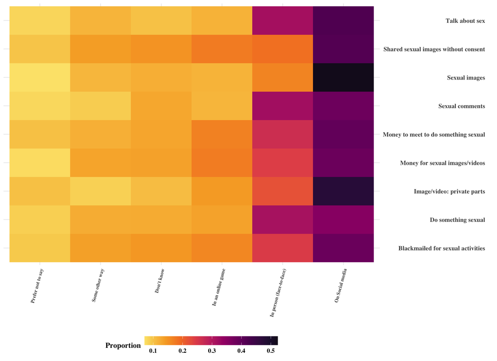

```r
# select location variables
place_list <- c(
  "inperson_",
  "socialmedia_",
  "onlinegame_",
  "someoway_",
  "pnotsay_",
  "dontknow_"
)

# relabel variables
place_labels <- c(
  socialmedia = "On Social media",
  inperson = "In person (face-to-face)",
  onlinegame = "In an online game",
  someoway = "Some other way",
  pnotsay = "Prefer not to say",
  dontknow = "Don't know"
)

# apply heatplot function
place_data <- heatplot_wrangling(ocsea_df, place_list, place_labels)
place_plot <- heatplot(place_data)
place_plot
```

```r
# convert to table
place_table <- place_data  %>%
  select(place, type, Proportion) %>%
  mutate(Proportion = paste0(round(Proportion * 100, 1), "%")) %>%
  pivot_wider(
    names_from = place,
    values_from = Proportion
  )

kable(place_table, format = "html", escape = TRUE)
```

| type | On Social media | In person (face-to-face) | In an online game | Don't know | Some other way | Prefer not to say |
| --- | --- | --- | --- | --- | --- | --- |
| Sexual images | 52.3% | 16.5% | 11.6% | 12.1% | 11.2% | 7.1% |
| Image/video: private parts | 47.5% | 22% | 14.2% | 10.6% | 8.6% | 10.3% |
| Talk about sex | 41.9% | 31.7% | 11.7% | 10.2% | 11.4% | 8.2% |
| Shared sexual images without consent | 41.4% | 18.6% | 17.4% | 14.9% | 13.9% | 9.9% |
| Money to meet to do something sexual | 39.4% | 26.5% | 16.9% | 13.1% | 12% | 10.3% |
| Blackmailed for sexual activities | 38.5% | 24.5% | 16.2% | 14.6% | 13.7% | 9.4% |
| Money for sexual images/videos | 38.4% | 24.2% | 17.2% | 13.4% | 13.3% | 7.6% |
| Sexual comments | 38.2% | 32% | 11.4% | 12.9% | 9% | 8% |
| Do something sexual | 35.3% | 31.4% | 13.3% | 12.4% | 12.4% | 8.8% |

```r
# save heatplot
ggsave(
  "place_plot.pdf",
  place_plot,
  width = 10,
  height = 6,
  dpi =300
  )
```

## Perpetrator Identity in Technology-Facilitated CSEA Incidents

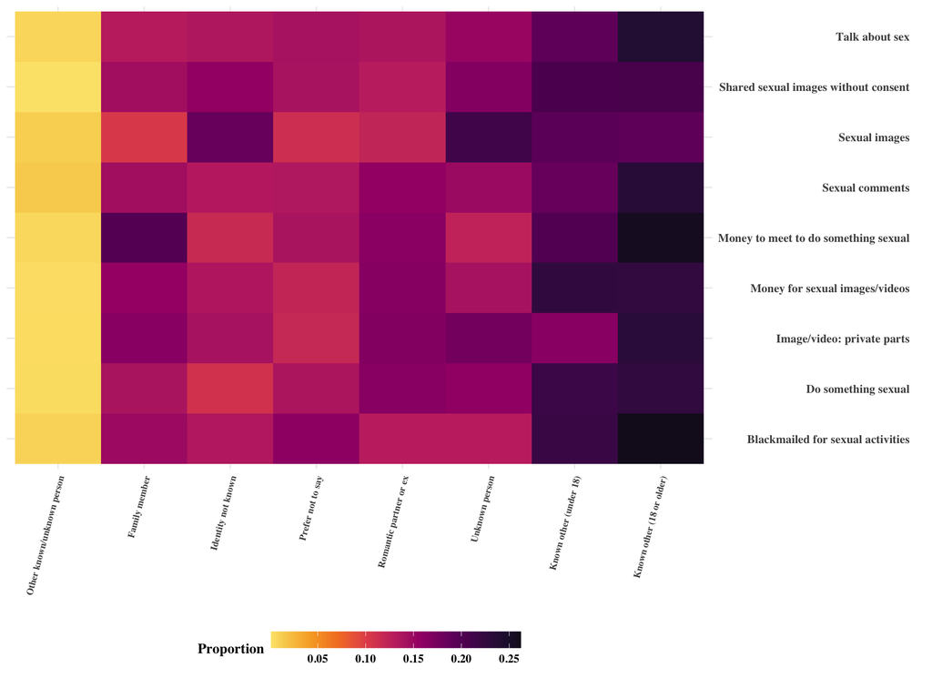

```r
# select variables
perp_list <- c(
  "known_",
  "knownr_",
  "knowno_",
  "knowno2_",
  "unknown_",
  "unknown2_",
  "unknown3_",
  "perpnotsay_"
)
# relabel Perpetrator Identity variables
perp_labels <- c(
  knowno2 = "Known other (under 18)",
  knowno = "Known other (18 or older)",
  unknown = "Unknown person",
  unknown2 = "Other known/unknown person",
  unknown3 = "Identity not known",
  known = "Family member",
  knownr = "Romantic partner or ex",
  perpnotsay = "Prefer not to say"
)


# heatplot function
perp_data <- heatplot_wrangling(ocsea_df, perp_list, perp_labels)
perp_plot <- heatplot(perp_data)
perp_plot
```

```r
# convert to table
perp_table <- perp_data  %>%
  select(place, type, Proportion) %>%
  mutate(Proportion = paste0(round(Proportion * 100, 1), "%")) %>%
  pivot_wider(
    names_from = place,
    values_from = Proportion
  )

kable(perp_table, format = "html", escape = TRUE)
```

| type | Known other (18 or older) | Known other (under 18) | Unknown person | Family member | Identity not known | Romantic partner or ex | Prefer not to say | Other known/unknown person |
| --- | --- | --- | --- | --- | --- | --- | --- | --- |
| Blackmailed for sexual activities | 26.2% | 22% | 13% | 15% | 13.4% | 13% | 15.9% | 0.9% |
| Money to meet to do something sexual | 25.8% | 20% | 12.4% | 19.9% | 11.7% | 16.1% | 13.9% | 0.6% |
| Talk about sex | 24% | 19.1% | 15.2% | 13.1% | 13.6% | 13.8% | 14.2% | 0.8% |
| Sexual comments | 23.4% | 18.6% | 15% | 14.5% | 13.3% | 15.6% | 13.5% | 1.5% |
| Image/video: private parts | 23.3% | 16.2% | 17.6% | 16.2% | 14.1% | 16.6% | 11.9% | 0.4% |
| Money for sexual images/videos | 22.4% | 22.7% | 14.1% | 15.5% | 13.6% | 16.4% | 12.2% | 0.4% |
| Do something sexual | 22.6% | 21.8% | 15.8% | 13.9% | 10.9% | 16.2% | 13.8% | 0.5% |
| Sexual images | 19% | 19.4% | 21.4% | 10.4% | 18.5% | 12.2% | 11.4% | 1.2% |
| Shared sexual images without consent | 20.7% | 20.4% | 16.6% | 14.5% | 15.5% | 13% | 14% | 0.1% |

```r
ggsave(
  "perp_plot.pdf",
  perp_plot,
  width = 14,
  height = 10,
  dpi =300
  )
```

## Checking the Perpetrator variable overlap

We created a categorical measure of perpetrator identity with four distinct levels based on children’s responses to the OCSEA (Online Child Sexual Exploitation and Abuse) module of the survey (see Figure 2). The four categories are: - Unknown: the perpetrator was a stranger or someone the child did not know prior to the incident. - Known romantic: the perpetrator was romantically associated with the child, such as a current or former boyfriend/girlfriend. - Known family: the perpetrator was a member of the child’s family. - Known other: the perpetrator was otherwise known to the child, such as a friend, peer, or acquaintance. These categories were derived by grouping individual binary perpetrator identity indicators into a combined variable reflecting any combination of the four perpetrator types

```r
# pivot perpetrator variables into long format
ocsea_long <- ocsea_df %>%
  pivot_longer(
    cols = matches("^(known|unknown)"),
    names_to = "variable",
    values_to = "value"
  )

# recode variables into 4 perpetrator categories
DH_long <- ocsea_long %>%
  filter(value == 1 & victim == 1) %>%
  mutate(Type = case_when(
    grepl("^knowno2?_", variable) ~ "other",
    grepl("^unknown\\d*_", variable) ~ "unknown",
    grepl("^knownr_", variable) ~ "romantic",
    grepl("^known_", variable) ~ "family",
    TRUE ~ NA_character_
  )) %>%
  filter(!is.na(Type)) %>%
  group_by(CBU_ID, Type) %>%
  summarise(
    Score = as.integer(any(value == 1)),
    .groups = "drop"
  )

# pivot to wide binary format
perp_binary <- DH_long %>%
  pivot_wider(
    names_from = Type,
    values_from = Score,
    values_fill = list(Score = 0)
  ) %>%
  distinct()

# Merge back into main dataset by ID
ocsea_df <- ocsea_df %>%
  left_join(perp_binary, by = "CBU_ID")

# create 4-level main perpetrator type variable
# (unknown > romantic > family > other)
ocsea_df <- ocsea_df %>%
  rowwise() %>%
  mutate(
    Perp = case_when(
      unknown == 1 ~ "unknown",
      romantic == 1 ~ "romantic",
      family == 1 ~ "family",
      other == 1 ~ "other",
      TRUE ~ NA_character_
    )
  ) %>%
  ungroup()

table(ocsea_df$Perp, useNA = "ifany")
```

```
  family    other romantic  unknown     <NA>
     163      380      345     1109     9915
```

```r
# all combinations of 0/1 across perpetrator types
ocsea_df <- ocsea_df %>%
  mutate(perp_pattern = interaction(unknown, romantic, family, other, sep = "_", drop = TRUE))
```

This shows the substantial overlap in perpetrator types, with a significant proportion of children experiencing abuse involving multiple categories. For example, 227 children (weighted) experienced both unknown and other known perpetrators, and 105 reported unknown, romantic, and other perpetrators. This overlap limits the construction of mutually exclusive categories, and thus perpetrator identity was excluded from the model. We therefore analyse perpetrator type descriptively rather than include it as a categorical variable in regression models.

```r
# refresh to ocsea_df
svy_overall <- survey::svydesign(id = ~1, weights = ~wgt_scaled, data = ocsea_df)

# get weighted frequencies of patterns
perp_weighted <- svytable(~perp_pattern, svy_overall)
perp_df <- as.data.frame(perp_weighted) %>%
  arrange(desc(Freq)) %>%
  rename(
    Pattern = perp_pattern,
    Weighted_frequency = Freq
  )

perp_df <- perp_df %>%
  mutate(
    Types = case_when(
      Pattern == "1_0_0_0" ~ "Unknown only",
      Pattern == "0_1_0_0" ~ "Romantic only",
      Pattern == "0_0_1_0" ~ "Family only",
      Pattern == "0_0_0_1" ~ "Other only",
      Pattern == "1_0_0_1" ~ "Unknown + Other",
      Pattern == "0_1_0_1" ~ "Romantic + Other",
      Pattern == "0_0_1_1" ~ "Family + Other",
      Pattern == "1_1_0_1" ~ "Unknown + Romantic + Other",
      Pattern == "0_1_1_1" ~ "Romantic + Family + Other",
      Pattern == "1_0_1_1" ~ "Unknown + Family + Other",
      Pattern == "1_1_1_1" ~ "All four types",
      Pattern == "1_1_0_0" ~ "Unknown + Romantic",
      Pattern == "1_0_1_0" ~ "Unknown + Family",
      Pattern == "0_1_1_0" ~ "Romantic + Family",
      Pattern == "1_1_1_0" ~ "Unknown + Romantic + Family",
      Pattern == "0_0_0_0" ~ "No perpetrator reported",
      TRUE ~ "Other combination"
    )
  )

perp_df
```

```
   Pattern Weighted_frequency                       Types
1  1_0_0_0          545.56316                Unknown only
2  0_0_0_1          369.45391                  Other only
3  1_0_0_1          226.92775             Unknown + Other
4  0_1_0_1          115.95744            Romantic + Other
5  1_1_0_1          105.45652  Unknown + Romantic + Other
6  0_1_0_0           92.75728               Romantic only
7  0_0_1_0           89.61768                 Family only
8  0_0_1_1           82.69822              Family + Other
9  0_1_1_1           79.50037   Romantic + Family + Other
10 1_0_1_1           57.97988    Unknown + Family + Other
11 1_1_1_1           54.89060              All four types
12 1_1_0_0           41.40119          Unknown + Romantic
13 1_0_1_0           39.01751            Unknown + Family
14 0_1_1_0           32.18248           Romantic + Family
15 1_1_1_0           15.60827 Unknown + Romantic + Family
```

## Online Platforms Involved in Technology-Facilitated CSEA Incidents

```r
# prepare platform data
allplatforms <- ocsea_df %>%
  select(wgt_scaled, starts_with("platform_")) %>%
  select(
    -ends_with("other"),
    -ends_with("888"),
    -ends_with("999")
  ) %>%
  pivot_longer(
    cols = -wgt_scaled,
    names_prefix = "platform_"
  ) %>%

  # separate CSEA type (a–i) and platform number
  separate(name, into = c("type", "platform"), sep = "[.]") %>%

  # keep valid platforms (1 to 17 as per the codebook)
  filter(as.numeric(platform) <= 17, !is.na(value)) %>%

  # apply weights
  group_by(type, platform) %>%
  summarise(Proportion = sum(value * wgt_scaled, na.rm = TRUE) / sum(wgt_scaled[!is.na(value)]),
            .groups = "drop") %>%
  arrange(-Proportion) %>%
  mutate(
    type = recode(
      type,
      "a" = "Sexual comments",
      "b" = "Sexual images",
      "c" = "Talk about sex",
      "d" = "Do something sexual",
      "e" = "Image/video: private parts",
      "f" = "Money for sexual images/videos",
      "g" = "Money to meet to do something sexual",
      "h" = "Shared sexual images without consent",
      "i" = "Blackmailed for sexual activities"
    ),
    platform = recode(
      platform,
      `1` = "Facebook or Messenger",
      `2` = "Twitter",
      `3` = "Snapchat",
      `4` = "Instagram",
      `5` = "TikTok",
      `6` = "WhatsApp",
      `7` = "Line",
      `8` = "YouTube",
      `9` = "Tumblr",
      `10` = "Flickr",
      `11` = "Live.me",
      `12` = "Periscope",
      `13` = "Twitch",
      `14` = "Discord",
      `15` = "Other",
      `16` = "Don't know",
      `17` = "Prefer not to say"
    )
  )
```

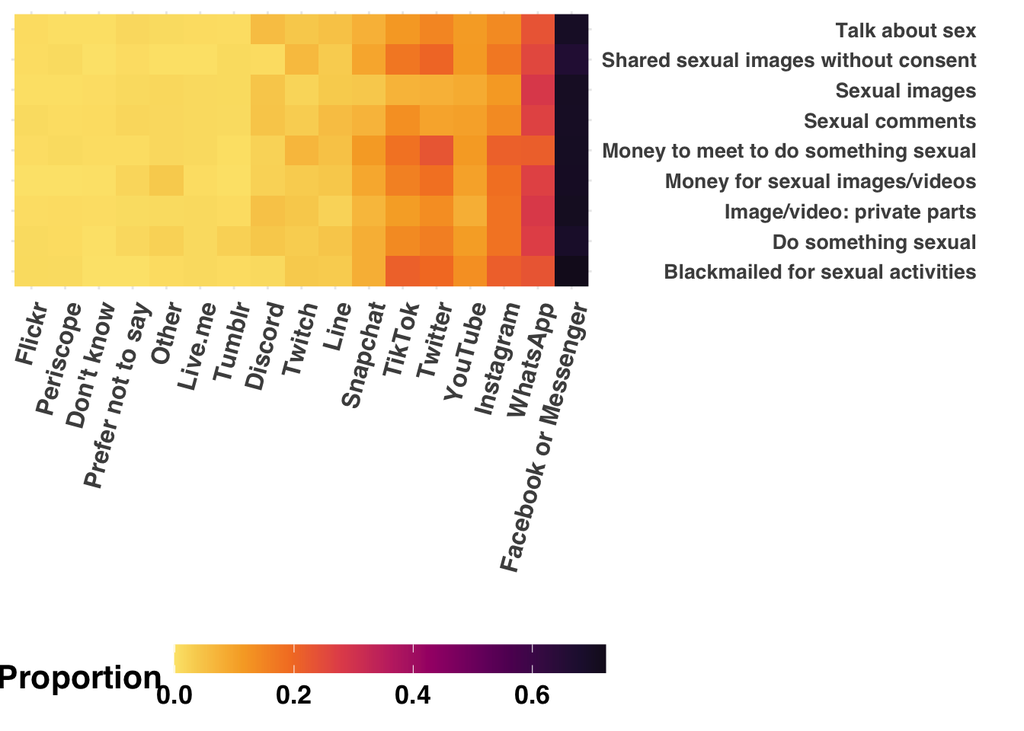

```r
# create heatplot for platform-specific CSEA
allplatforms_heatplot <- function(data) {
  data <- data %>%
    mutate(
      platform = factor(
        platform,
        levels = unique(data$platform[order(data$Proportion)])
      )
    )

  plot <- ggplot(data, aes(x = platform, y = type)) +
    geom_raster(aes(fill = Proportion)) +
    scale_y_discrete(position = "right") +
    scale_fill_continuous_sequential(
      palette = "Inferno",
      begin = 0.06,
      end = 0.95,
      name = "Proportion"
    ) +
    theme_minimal(base_family = "Helvetica") +
    theme(
      axis.text.x = element_text(
        face = "bold",
        angle = 75,
        hjust = 1,
        vjust = 1,
        size = 12
      ),
      axis.text.y = element_text(
        face = "bold",
        size = 10
      ),
      legend.position = "bottom",
      legend.key.size = unit(0.7, "cm"),
      legend.key.height = unit(0.5, "cm"),
      legend.key.width = unit(1.5, "cm"),
      strip.background = element_blank(),
      panel.spacing = unit(4, "mm"),
      text = element_text(size = 16, face = "bold")
    ) +
    labs(x = "", y = "")

  return(plot)
}

# apply heatplot function
plat <- allplatforms_heatplot(allplatforms)
plat
```

```r
full_plat <- allplatforms %>%
  select(platform, type, Proportion) %>%
  complete(platform, type)

plat_table <- full_plat %>%
  mutate(
    Proportion = ifelse(is.na(Proportion), "0%", paste0(round(Proportion * 100, 1), "%"))
  ) %>%
  pivot_wider(
    names_from = type,
    values_from = Proportion
  )
kable(plat_table, format = "html", escape = TRUE)
```

| platform | Blackmailed for sexual activities | Do something sexual | Image/video: private parts | Money for sexual images/videos | Money to meet to do something sexual | Sexual comments | Sexual images | Shared sexual images without consent | Talk about sex |
| --- | --- | --- | --- | --- | --- | --- | --- | --- | --- |
| Discord | 1.2% | 3.9% | 4.8% | 2.3% | 2.2% | 4.5% | 4.3% | 0.8% | 5.6% |
| Don't know | 0% | 0.2% | 0.5% | 0.2% | 0.7% | 0.8% | 0.5% | 0% | 0.3% |
| Facebook or Messenger | 72.3% | 69% | 70.9% | 70.3% | 70.1% | 69.9% | 70.1% | 66.2% | 69.7% |
| Flickr | 1% | 0.9% | 0.5% | 0% | 0.5% | 0.9% | 0.4% | 0.7% | 0.8% |
| Instagram | 21.4% | 17.8% | 17.9% | 18.7% | 21.1% | 14% | 11.6% | 17.1% | 14.1% |
| Line | 3.3% | 4.2% | 2% | 3.9% | 4.9% | 5.6% | 3.5% | 3.2% | 4.9% |
| Live.me | 1.1% | 1.1% | 1.2% | 0.6% | 1.2% | 1.2% | 1.1% | 0.3% | 0.7% |
| Other | 0.8% | 2.3% | 1% | 3.7% | 1.3% | 1.3% | 1.4% | 0.2% | 0.9% |
| Periscope | 0.9% | 0.8% | 0.7% | 0% | 0.9% | 0.6% | 0.3% | 0.9% | 0.4% |
| Prefer not to say | 0% | 1.3% | 0.9% | 1.6% | 0.6% | 1.5% | 1.2% | 0.7% | 1.3% |
| Snapchat | 8% | 8.1% | 6.7% | 9.2% | 11.3% | 7.1% | 3.8% | 9.5% | 7.6% |
| TikTok | 21.1% | 14% | 10.9% | 15.7% | 18.1% | 13.3% | 7.3% | 17.3% | 11.7% |
| Tumblr | 0.8% | 2.4% | 0.7% | 0.3% | 0.5% | 1% | 1% | 1% | 0.7% |
| Twitch | 3.6% | 3.1% | 3.9% | 3.2% | 6.6% | 3% | 2% | 6.2% | 3.9% |
| Twitter | 19.6% | 16% | 13.4% | 18.4% | 23% | 9.8% | 7.6% | 20.2% | 14.8% |
| WhatsApp | 23.1% | 27.2% | 28.3% | 26.8% | 21.4% | 26.6% | 28.6% | 25.7% | 23.5% |
| YouTube | 13.2% | 11% | 8.1% | 10.2% | 11.4% | 10.4% | 8.7% | 11.3% | 11.2% |

```r
ggsave(
  "plat.pdf",
  plat,
  width = 14,
  height = 10,
  dpi =300
  )
```

# Variable Recoding

We now select and center all the variables appropriately

```r
d_victim <- ocsea_df  %>%
  select(
    contains("CBU_ID"),
    starts_with("abuse_"),
    starts_with("toldnoone_"),
    starts_with("police_"),
    starts_with("friend_"),
    starts_with("helpline_"),
    starts_with("sworker_"),
    starts_with("father_"),
    starts_with("sibling_"),
    starts_with("mother_"),
    starts_with("teacher_"),
    starts_with("other_"),
    starts_with("othera_"),
    starts_with("otheropen_"),
    starts_with("rprefer_"),
    starts_with("rdontknow_"),
    contains("unable_"),
    contains("ashamed_"),
    contains("disbelief_"),
    contains("trouble_"),
    contains("troublefam_"),
    contains("myfault_"),
    contains("notserious_"),
    contains("knowledge_"),
    contains("troubleother_"),
    contains("noaction_"),
    contains("friendsdis_"),
    contains("parentsdis_"),
    contains("noconfidential_"),
    contains("barrierso_"),
    contains("sex"),
    contains("wgt_scaled"),
    contains("age"),
    contains("sexed"),
    contains("COUNTRY"),
    contains("helpseeking"),
    contains("urbanrural"),
    contains("digitalskills"),
    contains("presex"),
    contains("nindex"),
    contains("parentmediate"),
    contains("victim"),
     contains("victim_all")

  )  %>%
  mutate(
  age = as.numeric(age),
  age = age - mean(age, na.rm = TRUE),
  across(
    c(presex, sexed, helpseeking),
    ~ factor(., levels = c(0, 1))
  )
)

# predictor coding
contrasts(d_victim$sex) <- c(-0.5, 0.5)
contrasts(d_victim$presex) <- c(-0.5, 0.5)
contrasts(d_victim$sexed) <- c(-0.5, 0.5)
contrasts(d_victim$helpseeking) <- c(-0.5, 0.5)
```